# Itô’s Lemma: From Black-Scholes to Diffusion Models

The math that prices a stock option is the math that helps generate images — Wall Street to AI labs, same machinery, different century.

stochastic calculus

diffusion models

generative AI

Itô's lemma

Black-Scholes

options pricing

DDPM

Itô’s lemma yields both the Black-Scholes equation and DDPM’s forward diffusion process from one rule, (dW)² = dt — a rigorous, self-contained tour of stochastic calculus connecting quantitative finance and generative AI.

Author

Aja S.

Published

August 2026

This series — Continuous-Time Generative Models

| Date | Title |
| --- | --- |
| Sep 10, 2026 | The Variational Bound (ELBO) and Score Matching: Two Routes to Denoising Diffusion |
| Aug 10, 2026 | Itô's Lemma: From Black-Scholes to Diffusion Models — you are here |

The first time I saw the forward process of a diffusion model written as an SDE by Song et al. [1], what struck me was not the idea but the notation. Change a few words — "noise schedule" for "volatility" — and it was an equation I had solved many times before. The process is presented as something new — a device for training image generators that adds a little Gaussian noise step after step until the data dissolves into pure noise. But the equation underneath was one I had spent years with in a different domain. I had seen that drift-plus-noise structure before; I had taken that same $N \to \infty$ limit before; I had used that same lemma to reduce a state-dependent SDE to one I could solve.

That lemma is Itô’s. In quantitative finance it is the engine behind the Black-Scholes equation: feed it a stochastic stock price, hedge away the randomness, and a deterministic PDE for the option’s fair value remains. In a diffusion model it performs two operations that look unrelated — applied one way it turns the noised state into a Gaussian that can be sampled in a single step; applied another it yields a PDE for how that noise spreads. Same lemma, two fields, half a century apart.

What connects them is a single rule of stochastic calculus, $(dW)^2 = dt$ — the one fact for which ordinary calculus has no term. Pricing derivatives, I had taken its consequences for granted. In image generation, the very same correction term reappears at the heart of the diffusion machinery. This post builds that rule from first principles and then applies it three times: to derive the Black-Scholes equation, to give the DDPM forward process its closed-form perturbation kernel, and to derive that process’s Fokker-Planck equation. One identity, carried to two ends of a bridge that quantitative finance and generative AI did not know they shared.

## Roadmap

This post is structured in six parts:

- **Part 1:** Develops Brownian motion — the foundational random process underlying all the SDEs in this series.
- **Part 2:** Introduces SDEs and Itô’s lemma — the calculus that turns Brownian inputs into derived processes.
- **Part 3:** Derives the Black-Scholes equation using Itô’s lemma — the canonical application from quantitative finance.
- **Part 4:** Shows that the forward process of DDPM [2], formulated as an SDE [1], is the same machinery applied to different questions.
- **Part 5:** Draws the three derivations together — Black-Scholes, the perturbation kernel, and the Fokker-Planck equation — comparing the effect of the Itô correction on each.
- **Part 6:** Discusses why this unification matters — for ML practitioners and for quants.

# 1 Brownian Motion

Part 1 begins with a glimpse of Brownian motion’s physics along with the two complementary views to see it. After that it constructs Brownian motion from first principles: first its defining properties, then the *quadratic variation* that measures a path’s accumulated squared fluctuation and reveals Brownian motion as continuous yet nowhere differentiable. That roughness is not incidental; it is the reason ordinary calculus fails here and a new one is required. Made precise, it yields the rule $(dW)^2 = dt$, the single identity on which the entire Itô calculus of Part 2 — and the SDEs of everything after — rests.

## 1.1 The physics

In 1827 the botanist Robert Brown watched particles released from pollen grains jitter randomly in water [3]. In 1905 Einstein explained it [4]: invisible water molecules bombard the particle, and the accumulation of countless random collisions produces a random, continuous path (Figure 1).

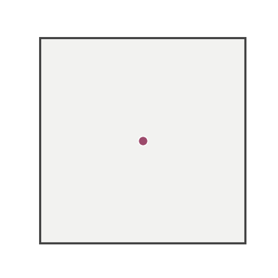

Figure 1: A particle released from a pollen grain, suspended in water and displaced along a ceaseless, irregular path by countless molecular collisions — the physical picture that Brownian motion idealizes. Each collision is independent of the last, and the particle reflects off the walls of its container. The animation cycles through several independent runs: each restart is a fresh, unrepeatable path.

The mathematics describing such a path — and, crucially, describing how the probability of finding the particle at each location spreads over time — comes in two complementary forms: an equation for the random trajectory of one particle (the **Langevin equation** [5]), and an equation for the evolving probability cloud of where it might be (the **Fokker-Planck equation**). These two views — one trajectory, one distribution — are the same physics seen two ways (Figure 2).

[figure not shown]

Figure 2: The two complementary descriptions of the same diffusing particle. **Left (trajectory view):** individual random paths $X_t$ of a particle buffeted by noise — each irregular, continuous, and unrepeatable — the object the Langevin equation describes. **Right (density view):** the probability cloud $p(x,t)$ of where the particle might be — dark and concentrated at first, then spreading and fading as probability is conserved — the object the Fokker-Planck equation describes. The identical $\pm\sqrt{t}$ envelope (dashed) traces the typical spread of the paths (the ±1-standard-deviation cone) on the left and the widening of the cloud on the right: one physics, two views.

That duality recurs through this entire blog series. In Part 2 of this first post it reappears as the two ways of applying Itô’s lemma: Pattern A follows the trajectory, Pattern B tracks the density (Section 2.3).

## 1.2 Definition

**Brownian motion** is the mathematical idealization of that path (Figure 1). It is the continuum limit of a random walk, as the steps shrink toward zero and grow infinitely frequent (Appendix A.1). Computing with it — integrating against it, transforming it, building SDEs on it — needs more than the informal picture, so the properties below specify the object precisely.

It is the foundational random process of continuous-time stochastic calculus — the noise source of every SDE in this series, from the stock-price models of Parts 2–3 to the diffusion-model forward process of Part 4 — and its defining surprise is a path that is continuous everywhere but differentiable nowhere.

Formally, a standard Brownian motion (or **Wiener process**) is a stochastic process $W_t$ on $[0, \infty)$ satisfying:

1. $W_0 = 0$
2. For $0 \le s < t$, the increment $W_t - W_s \sim \mathcal{N}(0,\, t - s)$
3. Increments over non-overlapping intervals are independent
4. The sample paths $t \mapsto W_t$ are continuous (almost surely)

[figure not shown]

Figure 3: Five independent sample paths of standard Brownian motion on $[0, 1]$, each starting at $W_0 = 0$ — the noise source underlying every SDE in this post. Every path is continuous yet irregular at every scale. Because the variance is $t$, the spread grows with time: the marginal $W_t \sim \mathcal{N}(0,\, t)$ widens (broader Gaussians, in rose), and the standard-deviation cone $\pm\sqrt{t}$ opens accordingly.

The properties imply a non-obvious fact: **although $W_t$ is continuous, its sample paths are not differentiable** (Figure 3). The route to it, and the ground of every later rule of Itô calculus, is the *quadratic variation* of $W$. What it delivers is that no continuously differentiable path survives; the stronger statement, that the paths are almost surely nowhere differentiable, is a theorem of Paley, Wiener and Zygmund [6], quoted in the geometric interpretation below.

## 1.3 Quadratic variation

Quadratic variation is the one quantity that distinguishes ordinary smooth functions from Brownian motion — and so identifies where differentiability fails. We define it first for an arbitrary continuous function, deliberately making no smoothness or randomness assumptions, and then evaluate that definition in the two cases that follow: a $C^1$ function (continuously differentiable — one with a continuous first derivative), where it collapses to zero, and a Brownian path, where it does not.

For a continuous, real-valued function $g: [0, t] \to \mathbb{R}$ and a partition $\Pi: 0 = t_0 < t_1 < \cdots < t_n = t$ with increments $\Delta t_i = t_{i+1} - t_i$ and mesh $\|\Pi\| = \max_{0 \le i \le n-1} \Delta t_i$, the **quadratic variation** of $g$ on $[0, t]$ is

$$\boxed{[g]_t \;=\; \lim_{\|\Pi\| \to 0} \sum_{i=0}^{n-1} \big(g(t_{i+1}) - g(t_i)\big)^2}
\tag{1}$$

when the limit exists.

## 1.4 Smooth functions have zero quadratic variation

Before turning to $W$, we compute $[g]_t$ for a smooth function as a baseline — it will vanish, and tracking *why* is what later determines what makes Brownian motion different. Each increment of a $C^1$ function is of order $\Delta t_i$, so its square is of order $(\Delta t_i)^2$ — one power of the mesh too small to survive the sum.

If $g \in C^1$ with $|g'| \le M$ on $[0, t]$ (where $M = \max_{s \in [0, t]} |g'(s)|$), then for some $\tau_i \in (t_i, t_{i+1})$ the mean-value theorem applied on each subinterval gives

$$g(t_{i+1}) - g(t_i) \;=\; g'(\tau_i)\,(t_{i+1} - t_i)$$

Squaring,

$$\big(g(t_{i+1}) - g(t_i)\big)^2 \;=\; \big(g'(\tau_i)\big)^2 (\Delta t_i)^2$$

Using $|g'| \le M$,

$$\big(g(t_{i+1}) - g(t_i)\big)^2 \;\le\; M^2 (\Delta t_i)^2$$

Summing across the partition,

$$\sum_{i=0}^{n-1} \big(g(t_{i+1}) - g(t_i)\big)^2 \;\le\; M^2 \sum_{i=0}^{n-1} (\Delta t_i)^2$$

Bounding $(\Delta t_i)^2 \le \|\Pi\|\, \Delta t_i$ since $\Delta t_i \le \|\Pi\|$,

$$\sum_{i=0}^{n-1} \big(g(t_{i+1}) - g(t_i)\big)^2 \;\le\; M^2\, \|\Pi\| \sum_{i=0}^{n-1} \Delta t_i$$

Telescoping $\sum_{i=0}^{n-1} \Delta t_i = t$,

$$\sum_{i=0}^{n-1} \big(g(t_{i+1}) - g(t_i)\big)^2 \;\le\; M^2\, \|\Pi\|\, t$$

Letting the mesh $\|\Pi\| \to 0$,

$$\sum_{i=0}^{n-1} \big(g(t_{i+1}) - g(t_i)\big)^2 \;\le\; M^2\, \|\Pi\|\, t \;\xrightarrow{\|\Pi\| \to 0}\; 0$$

So the partition sum is squeezed to zero — **smooth functions have $[g]_t = 0$**.

## 1.5 Brownian motion has quadratic variation $t$

**The smooth case was deterministic; this one is not.** In Section 1.4 the mean-value theorem fixed each increment at a definite value, so the partition sum was an ordinary number we could squeeze to zero. For Brownian motion there is no mean-value theorem — $W$ is nowhere differentiable — and the increments $\Delta W_i = W_{t_{i+1}} - W_{t_i}$ are *random*, which makes the sum $S = \sum_i (\Delta W_i)^2$ itself a random variable.

Thus, a pointwise squeeze is unavailable and “$[W]_t$” must be read as a probabilistic limit. So we show $S$ concentrates on a single deterministic value in $L^2$ (i.e. in mean square: $\mathbb{E}[(S - t)^2] \to 0$), in four steps:

1. Compute its **mean** (linearity of expectation, telescoping to $t$)
2. Compute its **variance** (Gaussian fourth moments, plus independent increments so variances add)
3. **Shrink the mesh** to send the variance to $0$ via the same inequality $\sum_i (\Delta t_i)^2 \le \|\Pi\|\,t$ as before, the difference being that it now eliminates a variance, not the sum itself
4. **Conclude** that mean $t$ with vanishing variance forces $S \to t$

For $W_t$, each increment satisfies $\Delta W_i \sim \mathcal{N}(0, \Delta t_i)$ — the common starting point for all four steps.

**Step 1 — the mean:**

By linearity of expectation,

$$\mathbb{E}\!\left[\sum_{i=0}^{n-1} (\Delta W_i)^2\right] \;=\; \sum_{i=0}^{n-1} \mathbb{E}\!\big[(\Delta W_i)^2\big]$$

Substituting $\mathbb{E}[(\Delta W_i)^2] = \Delta t_i$ (each $\Delta W_i \sim \mathcal{N}(0, \Delta t_i)$ is mean-zero, so its second moment equals its variance $\Delta t_i$),

$$\mathbb{E}\!\left[\sum_{i=0}^{n-1} (\Delta W_i)^2\right] \;=\; \sum_{i=0}^{n-1} \Delta t_i$$

Telescoping $\sum_i \Delta t_i = t$,

$$\mathbb{E}\!\left[\sum_{i=0}^{n-1} (\Delta W_i)^2\right] \;=\; t$$

**Step 2 — the variance:**

The increments are independent, so variances add across the sum,

$$\operatorname{Var}\!\left[\sum_{i=0}^{n-1} (\Delta W_i)^2\right] \;=\; \sum_{i=0}^{n-1} \operatorname{Var}\!\big((\Delta W_i)^2\big)$$

Substituting $\operatorname{Var}\!\big((\Delta W_i)^2\big) = 2(\Delta t_i)^2$, since $\operatorname{Var}(X^2) = \mathbb{E}[X^4] - \big(\mathbb{E}[X^2]\big)^2 = 3\sigma^4 - \sigma^4$ for $X \sim \mathcal{N}(0, \sigma^2)$ (with $\mathbb{E}[X^4] = 3\sigma^4$: write $X = \sigma Z$, and one Gaussian integration by parts gives $\mathbb{E}[Z^4] = 3$),

$$\operatorname{Var}\!\left[\sum_{i=0}^{n-1} (\Delta W_i)^2\right] \;=\; 2\sum_{i=0}^{n-1} (\Delta t_i)^2$$

**Step 3 — shrink the mesh:**

Applying the mesh inequality $\sum_i (\Delta t_i)^2 \le \|\Pi\|\, t$,

$$\operatorname{Var}\!\left[\sum_{i=0}^{n-1} (\Delta W_i)^2\right] \;\le\; 2\,\|\Pi\|\, t \;\xrightarrow{\|\Pi\|\to 0}\; 0$$

**Step 4 — conclude:**

The partition sum has mean $t$ and variance vanishing to zero, so it converges in $L^2$ to the deterministic limit:

$$\boxed{\,[W]_t \;=\; t\,}
\tag{2}$$

The quadratic variation of Brownian motion on $[0, t]$ is **exactly $t$, not zero** — a structural property of $W$, not an artifact of any specific partition. $\square$

### 1.5.1 Where smoothness made the difference

Both derivations look structurally similar — square the increment, sum across the partition, apply the mesh inequality — yet the smooth sum collapses to $0$ while the Brownian sum lands on $t$.

For the smooth function, the mean-value theorem and squaring allowed us to take $M^2$ out as a factor. As the expression was *degree 2 in $\Delta t_i$*, one factor of $\Delta t_i$ was absorbed by the mesh inequality and the other telescoped to $t$; once the limit $\|\Pi\| \to 0$ was applied, we found that $[g]_t = 0$.

For Brownian motion, $W$ isn’t differentiable, so we cannot apply the mean-value theorem and take $M^2$ out as a factor. Instead, the increments $\Delta W_i$ being *random* made the sum $S = \sum_i (\Delta W_i)^2$ itself a random variable, which forced us to take the mean-variance route. The variance vanished, eliminated by the mesh inequality as the smooth sum was, because it carries $(\Delta t_i)^2$. The mean did not, because $\mathbb{E}[(\Delta W_i)^2] = \Delta t_i$ leaves it *degree 1 in $\Delta t_i$*, and a degree-1 sum telescopes to $t$ instead of vanishing. That single power difference is the whole story:

Table 1: Where the smooth and Brownian quadratic-variation derivations diverge — and why one vanishes while the other doesn’t.

| Step | Smooth ($C^1$) | Brownian (mean) | Brownian (variance) |
| --- | --- | --- | --- |
| Per increment | $(\Delta g_i)^2 \le M^2 (\Delta t_i)^2$ | $\mathbb{E}[(\Delta W_i)^2] = \Delta t_i$ | $\operatorname{Var}\big((\Delta W_i)^2\big) = 2(\Delta t_i)^2$ |
| Sum across partition | $\sum (\Delta g_i)^2 \le M^2 \sum (\Delta t_i)^2$ | $\sum \mathbb{E}[(\Delta W_i)^2] = \sum \Delta t_i$ | $\sum \operatorname{Var}\big((\Delta W_i)^2\big) = 2\sum (\Delta t_i)^2$ |
| Degree in $\Delta t_i$ | $2$ | $1$ | $2$ |
| Mesh inequality applicable? | yes: $\sum (\Delta t_i)^2 \le \\|\Pi\\|\, t$ | no — no extra $\Delta t_i$ to absorb | yes: $\sum (\Delta t_i)^2 \le \\|\Pi\\|\, t$ |
| As $\\|\Pi\\| \to 0$ | $\;\le\; M^2\, \\|\Pi\\|\, t \;\to\; 0$ | $\;=\; t \;$ (constant in $\\|\Pi\\|$) | $\;\le\; 2\, \\|\Pi\\|\, t \;\to\; 0$ |

The smooth case has an **extra** $\Delta t_i$ per term that the mesh inequality absorbs — one factor becomes $\|\Pi\|$, the other telescopes to $t$, net bound $M^2\,\|\Pi\|\,t \to 0$. The Brownian case has only *one* factor of $\Delta t_i$ per term, so the sum telescopes to $t$ directly, with no extra $\Delta t_i$ left for the mesh inequality to absorb. **Differentiability buys that one extra power of $\Delta t_i$, and that one extra power is what makes the sum vanish.**

## 1.6 Geometric interpretation of why $[W]_t = t$ makes Brownian motion non-differentiable

The quadratic-variation results of the previous sections have a vivid geometric reading. A function’s local smoothness is what a *magnifying glass* reveals: zoom far enough into a differentiable curve and it looks like a straight line — its tangent — whereas zoom into a Brownian path and it stays as irregular as ever. The two subsections below make this contrast precise, and it is the same contrast that decides whether a squared increment survives in the limit.

### 1.6.1 Smooth functions

A differentiable function has a well-defined slope at every point. Geometrically that means it is *locally linear*: over a small step $\Delta t$ its increment is $f'(t)\,\Delta t = O(\Delta t)$, proportional to the step. Take even a high-curvature region and zoom in, and the curve bends less and less, settling toward its tangent line (Figure 4). For $f$ twice differentiable, the departure from the tangent over a window of width $\Delta t$ is the curvature term $\tfrac{1}{2} f''\,(\Delta t)^2 = O(\Delta t^2)$ — it shrinks faster than the window, so the squared increment is negligible next to $\Delta t$, which is why a smooth path has zero quadratic variation.

[figure not shown]

Figure 4: **Left:** a parabola with its horizontal tangent at the minimum (dashed), the dotted box marking the minimum region. **Right:** that boxed region magnified, at the same axis scale — the curve is far shallower and lies close to the tangent, with only a slight residual bend.

The magnified curve is shallower but not perfectly straight — a slight bend remains at finite zoom, and zooming further would reduce it further still, approaching a straight line in the limit. Because the bend shrinks this way, the squared increment is negligible: $(\Delta f)^2 = O(\Delta t^2) \to 0$ relative to $\Delta t$. This is the geometric face of the zero quadratic variation derived in Section 1.4. Brownian motion, we will now see, refuses to straighten.

### 1.6.2 Brownian motion

The quadratic-variation result $[W]_t = t$ (Equation 2) is the algebraic statement that a Brownian increment scales as $\Delta W \sim \sqrt{\Delta t}$. That square-root scaling has an immediate geometric consequence: the slope of a chord over a step is $\Delta W / \Delta t \sim 1/\sqrt{\Delta t} \to \infty$ as $\Delta t \to 0$, so the difference quotient blows up rather than converging to a finite slope, and the path is not continuously differentiable. In fact a classical theorem of Paley, Wiener and Zygmund [6] establishes the stronger property that Brownian paths are almost surely **nowhere differentiable**; the scaling here is the intuition behind that result, not a proof of it. Figure 5 makes this visible through *statistical self-similarity* [7]: zooming into any sub-interval and rescaling by the same $\sqrt{\Delta t}$ law reproduces a path just as irregular as the original, so there is no scale at which the path ever straightens out.

[figure not shown]

Figure 5: **Left:** a Brownian sample path on $[0, 1]$, with a small sub-interval $[a, b]$ boxed. **Right:** that boxed sub-interval, rescaled by $\times 20$ in time and $\times\sqrt{20}$ in value — the zoom is just as irregular as the whole path, with no smoother, straighter segment revealed.

The same $\sqrt{\Delta t}$ scaling is what makes a *squared* increment matter. A smooth curve flattens toward its tangent under magnification, so its increment is $O(\Delta t)$ and its square $O(\Delta t^2)$ — negligible. The Brownian path never flattens: its increment is $O(\sqrt{\Delta t})$, so its square is $O(\Delta t)$, the *same order as $dt$ itself*. That is the content of $[W]_t = t$, and it is why a squared Brownian increment cannot be discarded — the fact we turn into a precise calculus rule in the next section.

## 1.7 The $(dW)^2 = dt$ rule

What Equation 2 says at the level of infinitesimals is that $(\Delta W)^2$ behaves, in sum, like $\Delta t$. This is the meaning of the working rule

$$\boxed{(dW)^2 = dt}
\tag{3}$$

— *not* a literal pointwise equality of random variables, but a calculus rule for what sums of $(\Delta W)^2$ terms converge to inside an integral.

### 1.7.1 What the rule means inside an integral

The precise content of Equation 3 is an *integral* statement. For any bounded, Riemann-integrable deterministic function $f$ on $[0, t]$ (continuous suffices),

$$\boxed{\int_0^t f(s)\,(dW_s)^2 \;:=\; \lim_{\|\Pi\| \to 0} \sum_{i=0}^{n-1} f(t_i)\, (\Delta W_i)^2 \;=\; \int_0^t f(s)\, ds}
\tag{4}$$

with convergence in $L^2$ — the same calculation that gave $[W]_t = t$, now carrying the weight $f$.

**Mean:** By linearity of expectation,

$$\mathbb{E}\!\Big[\sum_i f(t_i)\, (\Delta W_i)^2\Big] \;=\; \sum_i f(t_i)\, \mathbb{E}\big[(\Delta W_i)^2\big]$$

Substituting $\mathbb{E}\big[(\Delta W_i)^2\big] = \Delta t_i$,

$$\mathbb{E}\!\Big[\sum_i f(t_i)\, (\Delta W_i)^2\Big] \;=\; \sum_i f(t_i)\, \Delta t_i$$

Letting the mesh $\|\Pi\| \to 0$ (a Riemann sum),

$$\mathbb{E}\!\Big[\sum_i f(t_i)\, (\Delta W_i)^2\Big] \;=\; \sum_i f(t_i)\, \Delta t_i \;\xrightarrow{\|\Pi\| \to 0}\; \int_0^t f(s)\, ds$$

**Variance:** By independence the variances add,

$$\operatorname{Var}\!\Big(\sum_i f(t_i)\, (\Delta W_i)^2\Big) \;=\; \sum_i \operatorname{Var}\big(f(t_i)\, (\Delta W_i)^2\big)$$

Taking each deterministic factor out squared,

$$\operatorname{Var}\!\Big(\sum_i f(t_i)\, (\Delta W_i)^2\Big) \;=\; \sum_i f(t_i)^2\, \operatorname{Var}\big((\Delta W_i)^2\big)$$

Substituting $\operatorname{Var}\big((\Delta W_i)^2\big) = 2(\Delta t_i)^2$,

$$\operatorname{Var}\!\Big(\sum_i f(t_i)\, (\Delta W_i)^2\Big) \;=\; 2 \sum_i f(t_i)^2\, (\Delta t_i)^2$$

Bounding $f(t_i)^2 \le \big(\sup_{[0,t]}|f|\big)^2$,

$$\operatorname{Var}\!\Big(\sum_i f(t_i)\, (\Delta W_i)^2\Big) \;\le\; 2\big(\sup_{[0,t]}|f|\big)^2 \sum_i (\Delta t_i)^2$$

Bounding $\sum_i (\Delta t_i)^2 \le \|\Pi\|\, t$ by the mesh,

$$\operatorname{Var}\!\Big(\sum_i f(t_i)\, (\Delta W_i)^2\Big) \;\le\; 2\big(\sup_{[0,t]}|f|\big)^2\, \|\Pi\|\, t$$

Letting the mesh $\|\Pi\| \to 0$,

$$\operatorname{Var}\!\Big(\sum_i f(t_i)\, (\Delta W_i)^2\Big) \;\le\; 2\big(\sup_{[0,t]}|f|\big)^2\, \|\Pi\|\, t \;\xrightarrow{\|\Pi\| \to 0}\; 0$$

A random variable whose mean converges to $\int_0^t f(s)\, ds$ and whose variance vanishes converges in $L^2$ to that limit, since $\mathbb{E}\big[(S - \int_0^t f\, ds)^2\big] = \operatorname{Var}(S) + \big(\mathbb{E}[S] - \int_0^t f\, ds\big)^2$ and both terms vanish. So the sum converges to $\int_0^t f(s)\, ds$ — which is the value Equation 4 asserts. $\square$ Setting $f \equiv 1$ specializes it to the plain quadratic variation Equation 2. So whenever $(dW)^2$ appears inside a stochastic integral with a deterministic weight, we may **substitute $dt$** for it, and the two integrals agree in the limit. Itô’s lemma will apply the rule with a random weight that depends only on the path up to that time. The same mean-and-variance argument goes through conditionally on that past, since the increment $\Delta W_i$ is independent of it.

### 1.7.2 Companion rules

Two further rules,

$$\boxed{(dt)^2 = 0}
\tag{5}$$

$$\boxed{dt\,dW = 0}
\tag{6}$$

follow by the same partition-sum reasoning, established next.

#### 1.7.2.1 The $(dt)^2$ rule is deterministic

This rule carries no randomness, so a single deterministic bound suffices — but the weight $f$ may change sign, so the bound must control the sum in absolute value. By the triangle inequality,

$$\Big|\sum_i f(t_i)\,(\Delta t_i)^2\Big| \;\le\; \sum_i |f(t_i)|\,(\Delta t_i)^2$$

Bounding the weight by $|f(t_i)| \le \sup_{[0,t]}|f|$,

$$\Big|\sum_i f(t_i)\,(\Delta t_i)^2\Big| \;\le\; \big(\sup_{[0,t]}|f|\big) \sum_i (\Delta t_i)^2$$

Bounding $\sum_i (\Delta t_i)^2 \le \|\Pi\|\, t$ by the mesh,

$$\Big|\sum_i f(t_i)\,(\Delta t_i)^2\Big| \;\le\; \big(\sup_{[0,t]}|f|\big)\, \|\Pi\|\, t$$

Letting the mesh $\|\Pi\| \to 0$,

$$\Big|\sum_i f(t_i)\,(\Delta t_i)^2\Big| \;\le\; \big(\sup_{[0,t]}|f|\big)\, \|\Pi\|\, t \;\xrightarrow{\|\Pi\| \to 0}\; 0$$

The bound is deterministic — no randomness enters — and it squeezes the partition sum to zero in absolute value as the mesh refines, so the sum itself converges to zero, giving the integral form

$$\int_0^t f(s)\,(ds)^2 = 0$$

whose equivalent differential form is $(dt)^2 = 0$, Equation 5.

#### 1.7.2.2 The $dt\,dW$ rule is an $L^2$ statement

The partition sum $\sum_i f(t_i)\, \Delta t_i\, \Delta W_i$ has mean zero, since each $\Delta W_i$ is mean-zero. For its variance, the increments are independent across non-overlapping intervals, so variances add,

$$\operatorname{Var}\!\Big(\sum_i f(t_i)\, \Delta t_i\, \Delta W_i\Big) \;=\; \sum_i \operatorname{Var}\big(f(t_i)\, \Delta t_i\, \Delta W_i\big)$$

Taking each deterministic factor out squared,

$$\operatorname{Var}\!\Big(\sum_i f(t_i)\, \Delta t_i\, \Delta W_i\Big) \;=\; \sum_i f(t_i)^2\, (\Delta t_i)^2\, \operatorname{Var}(\Delta W_i)$$

Substituting $\operatorname{Var}(\Delta W_i) = \Delta t_i$,

$$\operatorname{Var}\!\Big(\sum_i f(t_i)\, \Delta t_i\, \Delta W_i\Big) \;=\; \sum_i f(t_i)^2\, (\Delta t_i)^3$$

Bounding $f(t_i)^2 \le \big(\sup_{[0,t]}|f|\big)^2$,

$$\operatorname{Var}\!\Big(\sum_i f(t_i)\, \Delta t_i\, \Delta W_i\Big) \;\le\; \big(\sup_{[0,t]}|f|\big)^2 \sum_i (\Delta t_i)^3$$

Bounding two of the three factors of each $(\Delta t_i)^3$ by the mesh, $(\Delta t_i)^2 \le \|\Pi\|^2$,

$$\operatorname{Var}\!\Big(\sum_i f(t_i)\, \Delta t_i\, \Delta W_i\Big) \;\le\; \big(\sup_{[0,t]}|f|\big)^2\, \|\Pi\|^2 \sum_i \Delta t_i$$

Telescoping $\sum_i \Delta t_i = t$,

$$\operatorname{Var}\!\Big(\sum_i f(t_i)\, \Delta t_i\, \Delta W_i\Big) \;\le\; \big(\sup_{[0,t]}|f|\big)^2\, \|\Pi\|^2\, t$$

Letting the mesh $\|\Pi\| \to 0$,

$$\operatorname{Var}\!\Big(\sum_i f(t_i)\, \Delta t_i\, \Delta W_i\Big) \;\le\; \big(\sup_{[0,t]}|f|\big)^2\, \|\Pi\|^2\, t \;\xrightarrow{\|\Pi\| \to 0}\; 0$$

The partition sum thus has mean zero and a variance vanishing to zero as the mesh refines. A sequence with mean zero whose variance tends to zero converges to zero in $L^2$, so the partition sum converges in $L^2$ to zero, giving the integral form

$$\int_0^t f(s)\, ds\, dW_s = 0$$

whose equivalent differential form is $dt\,dW = 0$, Equation 6.

So **only $(dW)^2$ survives at first order in $dt$** — and what survives, by Equation 4, is $dt$.

## 1.8 The Itô integral: a Gaussian under $L^2$

The same partition-sum construction determines one more object used throughout: the **Itô integral** of a deterministic function against Brownian motion, $\int_0^t g(s)\, dW_s := \lim_{\|\Pi\| \to 0} \sum_i g(t_i)\, \Delta W_i$ — the left-endpoint limit of partition sums, as in Equation 4 but now *linear* in $\Delta W_i$ instead of $(\Delta W_i)^2$. Defining it rigorously for general *random* integrands is carried out in Appendix A.4 [7]; the deterministic case is all the closed-form solutions of this post need, and there the Wiener increment structure alone fixes the full distribution. The Fokker-Planck derivation of Part 4 uses one property of the random case, its zero mean, and takes it from that appendix.

**For deterministic $g$,**

$$\boxed{\int_0^t g(s)\, dW_s \;\sim\; \mathcal{N}\!\left(0,\;\; \int_0^t g(s)^2\, ds\right)}
\tag{7}$$

**Why:** Approximate the integral by a partition sum $\sum_i g(t_i)\, \Delta W_i$, with independent increments $\Delta W_i \sim \mathcal{N}(0, \Delta t_i)$. A finite linear combination of independent Gaussians is Gaussian, so each partition sum is Gaussian; its mean vanishes term by term, and by independence its variance is $\sum_i g(t_i)^2\, \Delta t_i \to \int_0^t g(s)^2\, ds$ (a Riemann sum, $g$ continuous).

As $\|\Pi\| \to 0$ the sums converge in $L^2$ to the integral, because each partition sum is the integral of a step function, and those integrals form a Cauchy sequence in $L^2$ as the mesh refines — the construction carried out in Appendix A.4. Because $L^2$ convergence carries the mean and variance to the limit, the limit has mean $0$ and variance $\int_0^t g^2\, ds$; and a mean-square limit of Gaussians is itself Gaussian — the Gaussian family is closed under $L^2$ limits, proved in Appendix A.6 — so the integral is Gaussian. The variance identity is the **Itô isometry**; the zero mean follows from the **martingale property** of the Itô integral.

**Martingale property:** (made precise in Appendix A.5) A *martingale* is a process with no systematic trend — given everything observed up to the present, its expected future value equals its present value. The Itô integral $M_t = \int_0^t g(s)\, dW_s$ is one, and since it starts at $M_0 = 0$, taking expectations gives $\mathbb{E}[M_t] = 0$ for every $t$ — on average it neither rises nor falls. This is the zero-mean half of Equation 7.

**Itô isometry:** An *isometry* is a map that preserves size. The map $g \mapsto \int_0^t g\, dW_s$ sends a function to a random variable while preserving the $L^2$ norm: $\mathbb{E}\big[\big(\int_0^t g(s)\, dW_s\big)^2\big] = \int_0^t g(s)^2\, ds$ — the mean-square size of the integral equals the ordinary size of the integrand. This is the variance half of Equation 7.

# 2 SDEs and Itô’s Lemma

Brownian motion is undirected noise — a continuous but nowhere-differentiable path whose only quantitative descriptor is its quadratic variation $[W]_t = t$, expressed in the working rule $(dW)^2 = dt$. On its own it has zero drift and a fixed, state-independent variance rate, so it models no particular system; this part builds state-dependent processes from it. First, SDEs define the process — a drift term that adds deterministic direction, a diffusion term that scales the noise — and then Itô’s lemma gives the calculus for transforming such processes, with the surviving $(dW)^2 = dt$ correction doing all the work. Together they are the engine we run in Parts 3 and 4.

## 2.1 Stochastic differential equations

Brownian motion is pure, undirected noise — mean-zero increments whose variance accumulates at unit rate (Equation 2). Real systems rarely behave so simply: a stock price exhibits a trend, a temperature relaxes toward ambient, a population grows — each carrying its own *deterministic* tendency while still being buffeted by randomness, often responding to that noise with an intensity that depends on the current state. To describe such a process we specify not its value but its *instantaneous change* — a deterministic push over $dt$ plus a scaled increment of $W_t$ — and let those infinitesimal updates accumulate into a path.

A (one-dimensional) Itô stochastic differential equation (SDE) has the form

$$\boxed{dX_t = \mu(X_t, t)\, dt + \sigma(X_t, t)\, dW_t}
\tag{8}$$

where $\mu$ is the *drift coefficient* and $\sigma$ is the *diffusion coefficient*. The notation $dX_t$, $dt$, $dW_t$ is shorthand for the integral equation

$$\boxed{X_t = X_0 + \int_0^t \mu(X_s, s)\, ds + \int_0^t \sigma(X_s, s)\, dW_s}
\tag{9}$$

where the second integral is the Itô integral of Section 1.8. There the integrand is deterministic; here $\sigma(X_s, s)$ is generally state-dependent and therefore random, but the same heuristic form is all that is needed here.

The drift term governs the deterministic evolution of $X_t$; the diffusion term governs the size of random fluctuations. Conditions under which such an SDE has a unique solution — global Lipschitz and linear growth on $\mu$ and $\sigma$ — are stated, with a proof sketch, in Appendix A.1 of post #3; every process in this post satisfies them, and post #3 states the conditions its learned reverse-time drift must meet.

The next two subsections introduce two concrete instances of this form — geometric Brownian motion (GBM) and the Ornstein-Uhlenbeck (OU) process — each obtained by choosing the drift and diffusion coefficients $\mu(x,t)$ and $\sigma(x,t)$. We solve both later with Itô’s lemma (GBM in Section 2.4.1, the OU process in Section 2.4.2), and both recur downstream: the former as the Black-Scholes stock model in Part 3, the latter as the template for the DDPM forward process in Part 4.

### 2.1.1 Geometric Brownian motion

In the Black-Scholes framework, $S_t$ denotes the price of a stock at time $t$, and is modeled by the SDE

$$\boxed{dS_t \;=\; \mu\, S_t\, dt \;+\; \sigma\, S_t\, dW_t}
\tag{10}$$

with scalar constants $\mu, \sigma$. This is Equation 8 with drift coefficient $\mu(x, t) = \mu\, x$ and diffusion coefficient $\sigma(x, t) = \sigma\, x$ — both *linear in $x$*. (The symbols $\mu, \sigma$ are reused here as scalar constants, distinct from the coefficient functions $\mu(x,t), \sigma(x,t)$ of Equation 8 — standard finance notation.)

The parameters have precise finance meanings:

- **Drift ($\mu$):** The instantaneous expected rate of return per unit time, $\mathbb{E}[dS_t/S_t] = \mu\, dt$. $\mu = 0.15$ means a $15\%$ per-year expected return (with $t$ measured in years); the *continuously-compounded* growth rate is the smaller $\mu - \tfrac{1}{2}\sigma^2$ (the Itô correction, derived below).
- **Volatility ($\sigma$):** The standard deviation of the return per unit time. $\sigma = 0.20$ means $20\%$ per-year volatility.

[figure not shown]

Figure 6: Sample paths of geometric Brownian motion with $\mu = 0.15$, $\sigma = 0.35$, $S_0 = 1$ over one year (a larger $\sigma$ than the $0.20$ example in the text, chosen so the skew below is visible). The dashed line is the deterministic expected value $\mathbb{E}[S_t] = S_0\, e^{\mu t}$. Paths trend upward in expectation but remain strictly positive throughout. The right panel is the marginal distribution of the endpoint $S_1$ (histogram of many paths, analytic density in rose): it is *lognormal* — right-skewed with a long upper tail and bounded below by zero — the property guaranteed by the model and derived in Section 2.4.1.

Sample paths trend upward in expectation while remaining strictly positive (Figure 6). We solve this SDE for the full distribution of $S_t$ — applying Itô’s lemma to $\log S_t$ — in Section 2.4.1, where the price is shown to be **lognormally distributed**.

### 2.1.2 Ornstein-Uhlenbeck process

The OU process [8] is the canonical **mean-reverting** SDE. With state $X_t \in \mathbb{R}$, long-run mean $\bar\mu$, mean-reversion rate $\kappa > 0$, and constant volatility $\sigma > 0$,

$$\boxed{dX_t \;=\; \kappa\,(\bar\mu - X_t)\, dt \;+\; \sigma\, dW_t}
\tag{11}$$

This is Equation 8 with drift coefficient $\kappa(\bar\mu - x)$ (linear in $x$, restoring toward $\bar\mu$) and constant diffusion $\sigma$ (independent of $x$).

The parameters:

- **Long-run mean ($\bar\mu$):** The value the process is pulled toward.
- **Mean-reversion rate ($\kappa$):** Units $1/\text{time}$; larger $\kappa$ pulls harder. The expected excursion decays as $e^{-\kappa t}$ (Equation 17, derived in Section 2.4.2), so its “half-life” — the time to halve — is $\ln 2 / \kappa$.
- **Volatility ($\sigma$):** The constant volatility of the noise, units $\text{state}/\sqrt{\text{time}}$.

**The mean-reversion intuition:** If $X_t > \bar\mu$, the drift $\kappa(\bar\mu - X_t) < 0$ pushes $X_t$ back down. If $X_t < \bar\mu$, the drift pushes it back up. The noise term $\sigma\, dW_t$ keeps the process jittering around $\bar\mu$ rather than converging to it (Figure 7).

[figure not shown]

Figure 7: Sample paths of an Ornstein-Uhlenbeck process with long-run mean $\bar\mu = 0$, mean-reversion rate $\kappa = 1$, and volatility $\sigma = 0.5$, started from several different points. Whatever the start, the drift pulls every path into the same stationary band $\bar\mu \pm \sqrt{\sigma^2/(2\kappa)}$ (shaded) around $\bar\mu$ (dashed). The right panel is a histogram of one long run: the paths settle into the stationary distribution $\mathcal{N}(0,\, \sigma^2/2\kappa)$ (solid curve), independent of where they began.

**Stationary distribution:** Unlike GBM — whose spread grows without bound (its log-return variance is $\sigma^2 t$, derived in Section 2.4.1) — OU has a *finite-variance equilibrium*. As $t \to \infty$,

$$\boxed{X_t \;\xrightarrow{\text{dist}}\; \mathcal{N}\!\left(\bar\mu,\;\, \frac{\sigma^2}{2\kappa}\right)}
\tag{12}$$

The equilibrium variance $\sigma^2/(2\kappa)$ arises from the balance between noise injection ($\sigma$) and restoring force ($\kappa$): more noise widens the spread, stronger reversion tightens it. The full derivation — solving the SDE by an integrating factor and letting $t \to \infty$ — is in Section 2.4.2 after Itô’s lemma is introduced.

**Where OU shows up:**

- **In finance:**
  - In interest-rate modeling, the [Vasicek model](https://en.wikipedia.org/wiki/Vasicek_model) [9] treats the instantaneous risk-free rate as an OU process.
  - In [statistical-arbitrage](https://en.wikipedia.org/wiki/Statistical_arbitrage), [cointegrated](https://en.wikipedia.org/wiki/Cointegration) price spreads — the difference between two related instruments — are modeled as mean-reverting OU processes.
- **In generative AI:**
  - OU is the simplest non-trivial **Langevin-style** SDE: it samples its Gaussian equilibrium $\mathcal{N}(\bar\mu,\, \sigma^2/(2\kappa))$ by mean reversion plus noise, and the same drift-plus-noise template lets Langevin dynamics sample any target distribution with a differentiable log-density (post #5).
  - The reverse, generative process of DDPM is that template generalized — a learned, time-dependent score $\nabla_x \log p_t$ replaces OU’s fixed linear drift, turning pure noise back into data (post #3).

## 2.2 Itô’s lemma

The SDEs of Section 2.1 describe how a state $X_t$ evolves; the question of interest is how *functions* of that state move. Given $dX_t = \mu\,dt + \sigma\,dW_t$, what SDE governs a transformed quantity $Y_t = f(X_t, t)$ — a log-price, an option value, a rescaled noised state? For a smooth, deterministic $X$ the ordinary chain rule would answer at once, but it fails here: the $(dW)^2 = dt$ rule of Equation 3 means a second-order term that classical calculus discards instead survives at order $dt$. Itô’s lemma resolves this — it is the ordinary chain rule plus exactly one correction term.

Let $X_t$ satisfy the SDE $dX_t = \mu\, dt + \sigma\, dW_t$, and let $f(x, t)$ be a function that is twice continuously differentiable in $x$ and once in $t$. Then according to Itô’s lemma the process $Y_t = f(X_t, t)$ satisfies [10]

$$\boxed{df = \left(\frac{\partial f}{\partial t} + \mu \frac{\partial f}{\partial x} + \frac{1}{2}\sigma^2 \frac{\partial^2 f}{\partial x^2}\right) dt + \sigma \frac{\partial f}{\partial x}\, dW}
\tag{13}$$

The term $\frac{1}{2}\sigma^2 \frac{\partial^2 f}{\partial x^2}\, dt$ is the *Itô correction*. It is what distinguishes Itô calculus from ordinary calculus.

### 2.2.1 Derivation

Taylor-expand $f(X_{t+dt}, t+dt)$ to second order in $x$ and first order in $t$ — all the smoothness $f$ is assumed to possess; the omitted higher terms are of order $dt \cdot dX$ and $(dt)^2$, which the companion rules Equation 6 and Equation 5 annihilate. The remainder of the second-order expansion is $o\big((dX)^2\big)$, and $(dX)^2$ is itself of order $dt$, so the remainder contributes nothing at order $dt$:

$$df \;=\; \frac{\partial f}{\partial t}\, dt \;+\; \frac{\partial f}{\partial x}\, dX \;+\; \tfrac{1}{2}\, \frac{\partial^2 f}{\partial x^2}\, (dX)^2$$

Substituting $dX = \mu\, dt + \sigma\, dW$,

$$df \;=\; \frac{\partial f}{\partial t}\, dt \;+\; \frac{\partial f}{\partial x}\,(\mu\, dt + \sigma\, dW) \;+\; \tfrac{1}{2}\, \frac{\partial^2 f}{\partial x^2}\, (\mu\, dt + \sigma\, dW)^2$$

Expanding the square,

$$df \;=\; \frac{\partial f}{\partial t}\, dt \;+\; \frac{\partial f}{\partial x}\,(\mu\, dt + \sigma\, dW) \;+\; \tfrac{1}{2}\, \frac{\partial^2 f}{\partial x^2}\,\bigl(\mu^2 (dt)^2 + 2\mu\sigma\, dt\, dW + \sigma^2 (dW)^2\bigr)$$

Reducing the squared increment via the companion rules $(dt)^2 = 0$, $dt\,dW = 0$, $(dW)^2 = dt$,

$$df \;=\; \frac{\partial f}{\partial t}\, dt \;+\; \frac{\partial f}{\partial x}\,(\mu\, dt + \sigma\, dW) \;+\; \tfrac{1}{2}\, \sigma^2\, \frac{\partial^2 f}{\partial x^2}\, dt$$

Distributing $\partial f / \partial x$ across the bracket,

$$df \;=\; \frac{\partial f}{\partial t}\, dt \;+\; \mu\, \frac{\partial f}{\partial x}\, dt \;+\; \sigma\, \frac{\partial f}{\partial x}\, dW \;+\; \tfrac{1}{2}\, \sigma^2\, \frac{\partial^2 f}{\partial x^2}\, dt$$

Grouping by $dt$ and $dW$ gives,

$$\boxed{df \;=\; \left(\frac{\partial f}{\partial t} \;+\; \mu\, \frac{\partial f}{\partial x} \;+\; \tfrac{1}{2}\, \sigma^2\, \frac{\partial^2 f}{\partial x^2}\right) dt \;+\; \sigma\, \frac{\partial f}{\partial x}\, dW}$$

which is Equation 13. $\square$

### 2.2.2 Comparison to the chain rule

Suppose we naively applied the *ordinary* chain rule to a stochastic $X$ with $dX = \mu\, dt + \sigma\, dW$ — substitute $dX$, stop at first order as we do in the ordinary case. We’d write

$$df \;\stackrel{?}{=}\; \left(\frac{\partial f}{\partial t} \;+\; \mu\, \frac{\partial f}{\partial x}\right) dt \;+\; \sigma\, \frac{\partial f}{\partial x}\, dW$$

That is what ordinary calculus would give — and in Itô calculus it is the *wrong* answer. Itô’s lemma is character-for-character the same, **except for one extra term** in the $dt$ coefficient:

$$df \;=\; \left(\frac{\partial f}{\partial t} \;+\; \mu\, \frac{\partial f}{\partial x} \;+\; \underbrace{\boxed{\tfrac{1}{2}\,\sigma^2\,\frac{\partial^2 f}{\partial x^2}}}_{\text{Itô correction — the square term}}\right) dt \;+\; \sigma\, \frac{\partial f}{\partial x}\, dW$$

The boxed second-order term is the **only structural difference** between the two equations. Every other character matches the naive chain rule. It is the surviving term from the $(dW)^2 = dt$ rule of Equation 3 — that partition-sum identity, promoted to a calculus correction.

### 2.2.3 The deterministic limit ($\sigma \to 0$)

A correct stochastic chain rule must reduce to the ordinary one when the noise is switched off — that is the sanity check.

Set $\sigma = 0$. The SDE loses its diffusion term,

$$dX_t = \mu\, dt$$

so $X$ is now a smooth (differentiable) path with derivative $\dot X = dX_t / dt = \mu$.

For a smooth path, $Y_t = f(X_t, t)$ changes for two reasons: $f$ depends on $t$ directly, and it depends on $t$ through $X_t$. The ordinary multivariable chain rule sums the two contributions — the explicit rate $\partial f / \partial t$, and the rate transmitted through $X$ moving at speed $\dot X$, namely $\dot X\, \partial f / \partial x$:

$$\frac{dY}{dt} \;=\; \frac{\partial f}{\partial t} \;+\; \dot X\, \frac{\partial f}{\partial x}$$

Substituting $\dot X = \mu$,

$$\frac{dY}{dt} \;=\; \frac{\partial f}{\partial t} \;+\; \mu\, \frac{\partial f}{\partial x}$$

Multiplying by $dt$,

$$dY \;=\; \left(\frac{\partial f}{\partial t} \;+\; \mu\, \frac{\partial f}{\partial x}\right) dt$$

Now set $\sigma = 0$ in Itô’s lemma. Starting from the full result,

$$df \;=\; \left(\frac{\partial f}{\partial t} \;+\; \mu\, \frac{\partial f}{\partial x} \;+\; \tfrac{1}{2}\, \sigma^2\, \frac{\partial^2 f}{\partial x^2}\right) dt \;+\; \sigma\, \frac{\partial f}{\partial x}\, dW$$

Setting $\sigma = 0$ — the second-order term $\tfrac{1}{2}\, \sigma^2\, \partial^2 f / \partial x^2$ and the $\sigma\, \partial f / \partial x\, dW$ term both vanish —

$$df \;=\; \left(\frac{\partial f}{\partial t} \;+\; \mu\, \frac{\partial f}{\partial x}\right) dt$$

The two agree exactly: with no noise, Itô’s lemma *is* the ordinary chain rule. The second-order term is what the $(dW)^2 = dt$ rule adds once $\sigma \neq 0$.

**Thus, Itô’s lemma = ordinary chain rule + $(dW)^2 = dt$ correction.**

## 2.3 Application patterns of Itô’s lemma

Two patterns will recur. In one, we follow the path a particle takes once it starts moving; in the other, we track the probability-density cloud, estimating how likely the particle is to be at a given place and time after its journey begins. Specifically, Pattern A rides along a single trajectory: it transforms one SDE into another, tracking some function of the moving state. Pattern B steps back to ask, at each time and place, how likely the state is to be there: it turns the SDE into a partial differential equation (PDE) for the probability density. Same lemma, same SDE — one follows the path, the other predicts the distribution. These are the two views of one diffusion introduced in Section 1.1, now made into two ways of applying the lemma.

**Pattern A:** Given an SDE for $X_t$, derive an SDE for a transformed quantity $f(X_t, t)$. It recurs in every part that follows:

- **Section 2.4.1:** $f(S) = \log S$ applied to the GBM stock price gives its closed-form lognormal distribution.
- **Section 2.4.2:** The integrating-factor transform $f(Z, t) = e^{\kappa t} Z$ applied to the long-run-mean-centered OU process gives its closed-form Gaussian distribution.
- **Section 3.3 – Section 3.7:** $f = V(S, t)$ applied to the GBM stock price yields the Black-Scholes PDE.
- **Section 4.9:** A similar integrating-factor transform $f(x, t) = x / \sqrt{\bar\alpha(t)}$ applied to the DDPM VP-SDE turns it into a driftless process, giving its closed-form Gaussian law — the perturbation kernel.

**Pattern B:** Given an SDE for $X_t$, derive a PDE for its probability density $p(x, t)$ — the Fokker-Planck equation. It appears once:

- **Section 4.10:** Applying Itô to a test function and taking expectations turns the VP-SDE into the Fokker-Planck equation for its marginal distribution $p(x, t)$, giving the PDE that governs how the DDPM forward process spreads the data density into noise over time.

## 2.4 Itô’s lemma solves GBM and the OU process

Itô’s lemma is most convincing in action. We turn it on the two example SDEs from Section 2.1 — GBM and the OU process — and in each case a single application collapses a state-dependent SDE into one we can integrate in closed form.

### 2.4.1 Solving GBM

We solve GBM for the full distribution of the price $S_t$ by applying Itô’s lemma to the transform $f(S) = \log S$ — a function of $S$ alone, with no explicit time dependence. ($\log S$ requires $S_t > 0$, so the step is valid while the price stays positive; the resulting solution Equation 14 is an exponential, strictly positive for all $t$, and applying Itô’s lemma to it recovers Equation 10, so it solves the SDE with no assumption on the sign. Uniqueness of the solution under the conditions of Section 2.1 makes it *the* solution, which discharges the assumption.)

#### 2.4.1.1 Use Itô to get reduced SDE

**The SDE:** The price $S_t$ follows the GBM SDE Equation 10,

$$dS_t \;=\; \mu\, S_t\, dt \;+\; \sigma\, S_t\, dW_t$$

**Itô’s lemma:** To avoid clashing with the GBM constants $\mu, \sigma$, write the generic lemma with drift coefficient $a$ and diffusion coefficient $b$ — that is, for a transform $f(S_t, t)$ of a process $dS_t = a\, dt + b\, dW_t$, the lemma Equation 13 reads

$$df \;=\; \left(\frac{\partial f}{\partial t} \;+\; a\, \frac{\partial f}{\partial S} \;+\; \tfrac{1}{2}\, b^2\, \frac{\partial^2 f}{\partial S^2}\right) dt \;+\; b\, \frac{\partial f}{\partial S}\, dW$$

To apply it to $f = \log S$ we need two elements: the coefficients $a, b$ — identified from the GBM equation — and the partials of $f$ — computed from $f = \log S$. We collect each, then substitute.

**Coefficients (from the GBM equation):** $a = \mu\, S_t$ and $b = \sigma\, S_t$.

**Partials (from $f = \log S$):**

$$\frac{\partial f}{\partial t} \;=\; 0, \qquad \frac{\partial f}{\partial S} \;=\; \frac{1}{S}, \qquad \frac{\partial^2 f}{\partial S^2} \;=\; -\frac{1}{S^2}$$

Substituting $a = \mu\, S$, $b = \sigma\, S$, and the three partials into the lemma,

$$d(\log S_t) \;=\; \left(0 \;+\; (\mu\, S) \cdot \frac{1}{S} \;+\; \tfrac{1}{2}\, (\sigma\, S)^2 \cdot \left(-\frac{1}{S^2}\right)\right) dt \;+\; (\sigma\, S) \cdot \frac{1}{S}\, dW_t$$

Simplifying,

$$d(\log S_t) \;=\; \left(\mu - \tfrac{1}{2}\sigma^2\right) dt + \sigma\, dW_t$$

a **constant-drift, constant-diffusion** SDE: both coefficients are independent of $S_t$.

#### 2.4.1.2 Solve reduced SDE by integration

Integrating this reduced SDE over $[0, t]$,

$$\log\!\left(\frac{S_t}{S_0}\right) \;=\; \big(\mu - \tfrac{1}{2}\sigma^2\big)\, t \;+\; \sigma \int_0^t dW_s$$

Since $W_0 = 0$, the Itô integral is $\int_0^t dW_s = W_t$,

$$\boxed{\log\!\left(\frac{S_t}{S_0}\right) \;=\; \big(\mu - \tfrac{1}{2}\sigma^2\big)\, t \;+\; \sigma\, W_t}
\tag{14}$$

#### 2.4.1.3 Properties of the solution distribution

Since $W_t \sim \mathcal{N}(0, t)$, the **log-return** is an affine function of a Gaussian — hence Gaussian:

$$\boxed{\log\!\left(\frac{S_t}{S_0}\right) \;\sim\; \mathcal{N}\!\Big(\, \big(\mu - \tfrac{1}{2}\sigma^2\big)\, t,\;\; \sigma^2\, t \,\Big)}
\tag{15}$$

Taking expectations of $S_t = S_0\, e^{(\mu - \sigma^2/2)t + \sigma W_t}$, with the deterministic factor pulled out,

$$\mathbb{E}[S_t] = S_0\, e^{(\mu - \sigma^2/2)t}\, \mathbb{E}[e^{\sigma W_t}]$$

Substituting the Gaussian moment $\mathbb{E}[e^{\sigma W_t}] = e^{\sigma^2 t/2}$, which follows by completing the square in the $\mathcal{N}(0, t)$ density,

$$\mathbb{E}[S_t] = S_0\, e^{\mu t}$$

The level grows at the full rate $\mu$ even as the typical log-return grows at $\mu - \tfrac{1}{2}\sigma^2$.

So log-returns have mean $(\mu - \tfrac{1}{2}\sigma^2)\, t$ and variance $\sigma^2 t$ — variance *linear* in time (characteristic of Brownian motion), so the standard deviation grows like $\sigma\sqrt{t}$. Equivalently, the price $S_t$ itself is lognormally distributed: its logarithm is Gaussian, which forces $S_t > 0$ always — essential, because stock prices can’t go negative.

The $-\tfrac{1}{2}\sigma^2$ term is the **Itô correction in action** (Figure 8). Naive chain-rule reasoning would give $d(\log S) = dS/S = \mu\, dt + \sigma\, dW$ — missing the $-\tfrac{1}{2}\sigma^2\, dt$ contribution that the $(dW)^2 = dt$ rule supplies. The mean of the log-return is therefore not $\mu\, t$ but $(\mu - \tfrac{1}{2}\sigma^2)\, t$; the gap is sometimes referred to in finance as the **volatility drag**.

[figure not shown]

Figure 8: The Itô correction, numerically. A single geometric Brownian motion path ($\mu = 0.10$, $\sigma = 0.40$) is generated by Euler-Maruyama on $dS = \mu S\, dt + \sigma S\, dW$ — the log-formula is *not* assumed — and then logged. The naive chain rule would predict $\log(S_t/S_0) = \mu t + \sigma W_t$, but the simulated log-return instead tracks $(\mu - \tfrac{1}{2}\sigma^2)\, t + \sigma W_t$. Both are driven by the *same* noise $W_t$, so they move in lockstep yet separate at the steady rate $\tfrac{1}{2}\sigma^2$: the shaded wedge is the $-\tfrac{1}{2}\sigma^2 t$ correction the naive rule omits.

### 2.4.2 Solving the OU process

The OU process Equation 11 is the mean-reverting counterpart, and the same lemma determines its long-run law. We solve it in closed form and recover the stationary distribution Equation 12.

#### 2.4.2.1 Use Itô to get reduced SDE

**The SDE:** The OU process Equation 11 is

$$dX_t \;=\; \kappa\,(\bar\mu - X_t)\, dt \;+\; \sigma\, dW_t$$

Centering on its long-run mean, $Z_t = X_t - \bar\mu$, so that the SDE becomes

$$dZ_t \;=\; -\kappa\, Z_t\, dt \;+\; \sigma\, dW_t$$

**Itô’s lemma:** For a transform $f(Z_t, t)$ of a process with drift coefficient $a$ and diffusion coefficient $b$ — that is, $dZ_t = a\, dt + b\, dW_t$ — the lemma Equation 13 reads

$$df \;=\; \left(\frac{\partial f}{\partial t} \;+\; a\, \frac{\partial f}{\partial Z} \;+\; \tfrac{1}{2}\, b^2\, \frac{\partial^2 f}{\partial Z^2}\right) dt \;+\; b\, \frac{\partial f}{\partial Z}\, dW$$

**Integrating factor:** The standard technique for a linear SDE is to apply Itô’s lemma to the transform $Y_t = f(Z_t, t)$ with $f(Z, t) = e^{\kappa t} Z$ — chosen so the explicit-time term cancels the drift.

**Coefficients (from the centered SDE):** $a = -\kappa\, Z_t$ and $b = \sigma$.

**Partials (from $f = e^{\kappa t} Z$):**

$$\frac{\partial f}{\partial t} \;=\; \kappa\, e^{\kappa t} Z, \qquad \frac{\partial f}{\partial Z} \;=\; e^{\kappa t}, \qquad \frac{\partial^2 f}{\partial Z^2} \;=\; 0$$

Substituting $a = -\kappa\, Z$, $b = \sigma$, and the three partials into the lemma,

$$d\!\left(e^{\kappa t} Z_t\right) \;=\; \Big(\kappa\, e^{\kappa t} Z \;+\; (-\kappa\, Z)\, e^{\kappa t} \;+\; \tfrac{1}{2}\, \sigma^2 \cdot 0\Big) dt \;+\; \sigma\, e^{\kappa t}\, dW_t$$

Simplifying — the explicit-time term $\kappa\, e^{\kappa t} Z$ and the drift term $-\kappa\, e^{\kappa t} Z$ cancel,

$$d\!\left(e^{\kappa t} Z_t\right) \;=\; \sigma\, e^{\kappa t}\, dW_t$$

#### 2.4.2.2 Solve reduced SDE by integration

Integrating from $0$ to $t$,

$$\int_0^t d\!\left(e^{\kappa s} Z_s\right) \;=\; \sigma \int_0^t e^{\kappa s}\, dW_s$$

Evaluating the left side, $\int_0^t d\!\left(e^{\kappa s} Z_s\right) = e^{\kappa t} Z_t - Z_0$,

$$e^{\kappa t} Z_t \;=\; Z_0 \;+\; \sigma \int_0^t e^{\kappa s}\, dW_s$$

As $Z_0 = X_0 - \bar\mu$,

$$e^{\kappa t} Z_t \;=\; (X_0 - \bar\mu) \;+\; \sigma \int_0^t e^{\kappa s}\, dW_s$$

Dividing by $e^{\kappa t}$,

$$Z_t \;=\; (X_0 - \bar\mu)\, e^{-\kappa t} \;+\; \sigma \int_0^t e^{-\kappa(t - s)}\, dW_s$$

Substituting $Z_t = X_t - \bar\mu$,

$$\boxed{X_t \;=\; \bar\mu \;+\; (X_0 - \bar\mu)\, e^{-\kappa t} \;+\; \sigma \int_0^t e^{-\kappa(t - s)}\, dW_s}
\tag{16}$$

#### 2.4.2.3 Properties of the solution distribution

Given $X_0$, the offset $\bar\mu + (X_0 - \bar\mu)e^{-\kappa t}$ is a deterministic constant, and the Itô integral is Gaussian by Equation 7; adding the constant leaves $X_t$ an affine function of that Gaussian, and an affine function of a Gaussian is Gaussian.

**Mean:** The Itô integral has zero mean by Equation 7, so

$$\boxed{\mathbb{E}[X_t] \;=\; \bar\mu \;+\; (X_0 - \bar\mu)\, e^{-\kappa t}}
\tag{17}$$

**Variance:** By Equation 7 with $g(s) = \sigma\, e^{-\kappa(t - s)}$,

$$\operatorname{Var}[X_t] \;=\; \sigma^2 \int_0^t e^{-2\kappa(t - s)}\, ds$$

Evaluating the integral,

$$\boxed{\operatorname{Var}[X_t] \;=\; \frac{\sigma^2}{2\kappa}\big(1 - e^{-2\kappa t}\big)}
\tag{18}$$

**Stationary distribution:** As $t \to \infty$ the decaying exponentials vanish — $e^{-\kappa t} \to 0$ in the mean and $e^{-2\kappa t} \to 0$ in the variance — so $\mathbb{E}[X_t] \to \bar\mu$ and $\operatorname{Var}[X_t] \to \sigma^2/(2\kappa)$. Since $X_t$ is Gaussian for every $t$, its law converges to

$$\boxed{\mathcal{N}\!\left(\bar\mu,\;\, \frac{\sigma^2}{2\kappa}\right)}$$

which is Equation 12. $\square$

# 3 Itô’s Lemma Derives the Black-Scholes Equation

With Itô’s lemma established — and already applied to GBM in Section 2.4.1 — we now turn it to the problem it was developed for: pricing a derivative on a traded stock. We keep the same GBM stock model Equation 10, apply the *same* lemma to an option’s value $V(S,t)$, and then hedge away the $dW$ exposure with a position in the stock; the random part cancels and a deterministic PDE results — the Black-Scholes equation, in which $r$ is the risk-free rate defined in Section 3.2:

$$\boxed{\,\frac{\partial V}{\partial t} + r S \frac{\partial V}{\partial S} + \frac{1}{2}\sigma^2 S^2 \frac{\partial^2 V}{\partial S^2} = r V\,}
\tag{19}$$

The rest of this part derives it.

## 3.1 What is an option?

An **option** is a contract whose value depends on — is *derived from* — the price of an underlying stock $S_t$. The contract grants its holder the **right, but not the obligation**, to buy or sell an agreed quantity of the stock at a pre-agreed price per share (strike, $K$) at a specified maturity ($T$). The two basic types are:

- **Call option:** Confers its buyer the right, but not the obligation, to **buy** an agreed quantity of the stock at the strike price $K$ at maturity $T$.
- **Put option:** Confers its buyer the right, but not the obligation, to **sell** an agreed quantity of the stock at the strike price $K$ at maturity $T$.

American options can be exercised at any time up to maturity $T$ while **European** options can be exercised only at the maturity $T$. This post restricts attention to **European** options; American options require additional theory beyond the present scope.

**Payoff at expiry:** At $t = T$, the option’s value depends only on $S_T$. A rational holder exercises the option only when doing so is profitable, giving the piecewise-linear *payoff functions*:

The **call payoff** is

$$\boxed{V_{\text{call}}(S_T) = \max(S_T - K,\, 0)}
\tag{20}$$

The holder exercises if $S_T > K$, gaining $S_T - K$; otherwise the option expires worthless.

The **put payoff** is

$$\boxed{V_{\text{put}}(S_T) = \max(K - S_T,\, 0)}
\tag{21}$$

The holder exercises if $S_T < K$, gaining $K - S_T$; otherwise the option expires worthless.

The kinked “hockey-stick” shape (Figure 9) is the structural signature of an option: identically zero on the unfavourable side of the strike, linear on the favourable side.

[figure not shown]

Figure 9: Payoff at expiry $t = T$ for European call (left) and put (right) options with strike $K = 100$. The call holder exercises only if $S_T > K$, receiving $S_T - K$; the put holder exercises only if $S_T < K$, receiving $K - S_T$. The kinked ‘hockey-stick’ shape — flat on the unfavourable side of the strike, linear on the favourable side — is the structural signature of an option.

## 3.2 Key finance terms

- **Risk-free rate:** The interest rate an investor can expect to earn on an investment that carries zero risk. In practice, usually the interest paid on a 10-year highly rated government Treasury note.
- **Risky asset:** An instrument whose future price is uncertain, evolving stochastically. In other words, the diffusion coefficient $\sigma(x, t)$ in its dynamics will not be $0$. For example, a stock.
- **Risk-free asset:** An instrument whose return is known in advance, carrying no price uncertainty. In other words, the **diffusion coefficient $\sigma(x, t)$ in its dynamics will be $0$**. For example, a bank account; a unit of cash held in it grows deterministically at the risk-free rate.
- **Long / short positions:** Holding $+q$ units of an instrument is being *long $q$*; owing $q$ units (selling now, buying back later) is being *short $q$* (a negative position, $-q$). A long position profits when the price rises; a short position profits when it falls.
- **Portfolio:** A collection of financial investments such as stocks, bonds, and options. If a portfolio has $i = 1, \dots, n$ instruments and the quantity and price of the $i$th instrument are $q_i$ and $P_i$ respectively, the **portfolio value** $\Pi_t$ (the symbol is standard in finance, and unrelated to the partition $\Pi$ of Part 1) is
  $$\Pi_t = \sum_{i=1}^{n} q_i\, P_i$$
- **Delta:** The sensitivity of an instrument’s value to a one-unit change in the stock price — the partial derivative of that value with respect to $S$.
- **Portfolio delta:** The sensitivity of the portfolio value to a one-unit change in the stock price, $\partial \Pi / \partial S$. Distributing the partial derivative through the sum,
  $$\frac{\partial \Pi}{\partial S} = \sum_{i=1}^{n} q_i\, \frac{\partial P_i}{\partial S}$$
- **Delta-neutral:** A portfolio with zero portfolio delta, $\partial \Pi / \partial S = 0$ — the quantities $q_i$ are chosen so the deltas of the instruments held cancel, leaving no delta exposure, so the portfolio is immune to a change in the stock price to first order.
- **Self-financing strategy:** A trading approach where a portfolio’s value changes only due to gains or losses from its assets, with no external cash inflows or withdrawals.

## 3.3 The option value process

Given the terminal payoff of Equation 20 as the boundary condition, pricing the option requires finding the SDE its *value* obeys — and Itô’s lemma provides it, applied to $V(S, t)$ under the same GBM stock dynamics we used for $\log S$ in Section 2.4.1.

Let $V(S, t)$ denote the **per-share** value of a European call option on $S$ with strike $K$ and maturity $T$. (Real option contracts typically represent multiple shares; the pricing is done per share throughout this derivation and scales linearly with quantity.) Assume $V$ is twice continuously differentiable in $S$ and once in $t$ for $t < T$ — the hypothesis of Equation 13; the closed-form solution of Section 3.7.1 confirms it for the call, the payoff’s kink at $S = K$ smoothing out instantly for $t < T$. Apply Itô’s lemma to $V$ under the GBM dynamics of Equation 10 (constant drift $\mu$, constant volatility $\sigma$):

$$dV = \left(\frac{\partial V}{\partial t} + \mu S \frac{\partial V}{\partial S} + \frac{1}{2}\sigma^2 S^2 \frac{\partial^2 V}{\partial S^2}\right) dt + \sigma S \frac{\partial V}{\partial S}\, dW_t
\tag{22}$$

The challenge that Black-Scholes addresses is the *prior* question: given today’s price $S_t$ and the stock-price dynamics, what is the fair value $V(S_t, t)$ of the option *before* expiry, for $t < T$? Itô’s lemma combined with a delta-neutral, risk-free portfolio of the stock and the option produces a PDE for $V$ whose **boundary condition** is the terminal call payoff $V(S, T) = \max(S - K,\, 0)$ (Equation 20).

## 3.4 Black-Scholes assumptions

The Black-Scholes derivation [11], [12] rests on a specific set of idealizing assumptions about the market and the assets traded in it. Collecting them upfront makes both the construction and its limitations transparent.

### 3.4.1 Market structure

The market consists of two instruments:

- A **risk-free asset** — a bank account or zero-coupon bond.
- A **risky asset** — a single stock with price $S_t$.

### 3.4.2 Assumptions on the assets

- **Risk-free asset dynamics:** The risk-free asset $B_t$ earns a continuously-compounded rate $r$ that does not vary with time,
  $$dB_t = r\, B_t\, dt$$
  Being risk-free, its diffusion term is $0$ — there is no $dW_t$ — so its value grows deterministically as $B_t = B_0\, e^{rt}$.
- **Stock dynamics:** The stock price follows the GBM dynamics of Equation 10, with *constant* drift $\mu$ and *constant* volatility $\sigma$,
  $$dS_t = \mu\, S_t\, dt + \sigma\, S_t\, dW_t$$
  Here the diffusion term is *not* $0$: the $\sigma\, S_t\, dW_t$ term is the source of the stock’s uncertainty, and is what makes it *risky*.
- **No dividends:** The stock pays no dividends over $[t, T]$.

### 3.4.3 Assumptions on the market

- **No arbitrage:** No strategy delivers a risk-free profit in excess of $r$. In particular, any two portfolios with identical payoffs in every future scenario must have identical prices today.
- **Frictionless trading:** Transactions are executed instantaneously with no fees, no bid–ask spread, no taxes, and no market impact. Continuous-time trading is permitted.
- **Unlimited borrowing and lending at $r$:** Cash may be borrowed or lent in any real-valued amount at the risk-free rate.
- **Unrestricted stock positions:** Any real-valued quantity of the stock may be held, including **short positions** (negative quantities), with no borrowing cost or quantity constraint.

The assumptions above are idealizations — real markets violate every one of them to some degree. Their utility is conceptual: under these conditions, the derivative-pricing problem reduces to a *well-posed PDE* with a known closed-form solution.

## 3.5 Black-Scholes pricing strategy

Given a European option with terminal payoff $V(S, T) = \max(S - K,\, 0)$ (Equation 20) and the option-value SDE Equation 22, the remaining argument unfolds in three steps:

1. **Form a hedged portfolio:** Construct a portfolio by holding $+1$ unit of the call option and $-\Delta_t$ units of the stock, where $\Delta_t = \partial V / \partial S$ is the option’s delta (Section 3.2), giving
   $$\Pi_t = V(S_t, t) - \Delta_t\, S_t$$
   The $dW_t$ contributions from $dV$ and from $\Delta_t\, dS_t$ cancel exactly, rendering the portfolio **instantaneously risk-free**. (Section 3.6)
2. **Invoke no-arbitrage:** A risk-free portfolio must earn the risk-free rate: $d\Pi_t = r\, \Pi_t\, dt$. Equating this with the deterministic dynamics from Step 1 yields a PDE for $V(S, t)$ — the **Black-Scholes PDE**. (Section 3.7)
3. **Solve the PDE:** Solving the PDE using the boundary condition $V(S, T) = \max(S - K,\, 0)$ (Equation 20) gives the Black-Scholes pricing formula for a European call.

## 3.6 The hedging portfolio

We want to hold the option together with something else so that the combined position is **delta-neutral** — its value insensitive to small moves in the stock price. Of the other instruments in the market, the risk-free asset has zero delta and cannot offset $S$-exposure, so the stock is the only candidate: hold the option long and a quantity $q_t$ of the stock, with $q_t$ to be determined:

$$\Pi_t = V(S_t, t) + q_t\, S_t$$

Its **portfolio delta** is the sensitivity of $\Pi_t$ to the stock price, computed from this definition (treating $q_t$ as constant in $S$ at the instant $t$):

$$\frac{\partial \Pi_t}{\partial S} = \frac{\partial V}{\partial S} + q_t
\tag{23}$$

Delta-neutrality requires $\partial \Pi_t/\partial S = 0$, which forces $q_t = -\partial V/\partial S = -\Delta_t$. Thus, the delta-neutral and risk-free portfolio is

$$\Pi_t = V(S_t, t) - \Delta_t S_t
\tag{24}$$

Over an infinitesimal interval, the portfolio changes by

$$d\Pi_t = dV - \Delta_t\, dS_t$$

Writing it this way drops the $-S_t\, d\Delta_t - d\Delta_t\, dS_t$ terms that the Itô product rule adds for a time-varying $\Delta_t$. This is **not** an approximation: the hedge is run as a *self-financing* strategy, so the cash released or absorbed by rebalancing the stock position is exactly offset by a cash account and nets to zero in $d\Pi_t$ over $[t, t+dt]$ — the accounting is in Appendix A.3.

**Step 1 — substitute the option change:**

Substituting Equation 22 (Itô’s lemma applied to $V$) for $dV$,

$$d\Pi_t \;=\; \left(\frac{\partial V}{\partial t} \;+\; \mu S\, \frac{\partial V}{\partial S} \;+\; \tfrac{1}{2}\, \sigma^2 S^2\, \frac{\partial^2 V}{\partial S^2}\right) dt \;+\; \sigma S\, \frac{\partial V}{\partial S}\, dW_t \;-\; \Delta_t\, dS_t$$

**Step 2 — substitute the stock change:**

Substituting Equation 10, $dS_t = \mu S\, dt + \sigma S\, dW_t$,

$$d\Pi_t \;=\; \left(\frac{\partial V}{\partial t} \;+\; \mu S\, \frac{\partial V}{\partial S} \;+\; \tfrac{1}{2}\, \sigma^2 S^2\, \frac{\partial^2 V}{\partial S^2}\right) dt \;+\; \sigma S\, \frac{\partial V}{\partial S}\, dW_t \;-\; \Delta_t\, \mu S\, dt \;-\; \Delta_t\, \sigma S\, dW_t$$

**Step 3 — collect like differentials:**

Grouping the $dt$ terms and the $dW_t$ terms,

$$d\Pi_t \;=\; \left(\frac{\partial V}{\partial t} \;+\; \mu S\, \frac{\partial V}{\partial S} \;-\; \Delta_t\, \mu S \;+\; \tfrac{1}{2}\, \sigma^2 S^2\, \frac{\partial^2 V}{\partial S^2}\right) dt \;+\; \left(\sigma S\, \frac{\partial V}{\partial S} \;-\; \Delta_t\, \sigma S\right) dW_t$$

**Step 4 — factor the paired terms:**

Factoring $\mu S$ out of the drift pair and $\sigma S$ out of the $dW_t$ pair,

$$d\Pi_t \;=\; \left(\frac{\partial V}{\partial t} \;+\; \mu S \left(\frac{\partial V}{\partial S} - \Delta_t\right) \;+\; \tfrac{1}{2}\, \sigma^2 S^2\, \frac{\partial^2 V}{\partial S^2}\right) dt \;+\; \sigma S \left(\frac{\partial V}{\partial S} - \Delta_t\right) dW_t$$

The same factor $\big(\partial V/\partial S - \Delta_t\big)$ now multiplies both the $\mu$-dependent drift and the entire $dW_t$ exposure.

**Step 5 — substitute the hedge:**

Substituting $\Delta_t = \partial V/\partial S$ (the position $q_t = -\Delta_t$ chosen above), both parentheses vanish at once,

$$d\Pi_t \;=\; \left(\frac{\partial V}{\partial t} \;+\; \tfrac{1}{2}\, \sigma^2 S^2\, \frac{\partial^2 V}{\partial S^2}\right) dt
\tag{25}$$

Vanishing of the first parentheses means that the expected return of the stock ($\mu$) has disappeared from the hedged portfolio’s dynamics, meaning the option’s fair value doesn’t depend on it. This implies that two investors who disagree about the stock’s expected return still agree on the option’s price (provided they agree on the volatility $\sigma$ and the risk-free rate $r$).

Similarly, vanishing of the second parentheses means that $d\Pi_t$ has become independent of $dW_t$ randomness entirely. So the same position choice $q_t = -\Delta_t$ creates a portfolio that is delta-neutral and $dW_t$-free.

This is the crux of the construction. In Equation 22 the term $\sigma S\, \partial V / \partial S\, dW_t$ made $dV$ random; Equation 25 has no $dW_t$ term at all. A position whose return depended on the random fluctuations of $S_t$ is rendered **instantaneously risk-free**, and the exposure was hedged away by adding a short stock position to our portfolio.

## 3.7 The Black-Scholes equation

Because the hedged portfolio $\Pi_t$ has no random component over $[t, t+dt]$, we invoke the **no-arbitrage condition** and assert that it must earn the risk-free rate $r$ — otherwise there would be a risk-free arbitrage. Thus:

$$d\Pi_t \;=\; r\, \Pi_t\, dt
\tag{26}$$

Substituting the portfolio definition $\Pi_t = V(S_t, t) - \Delta_t\, S_t$ from Equation 24,

$$d\Pi_t \;=\; r\, \big[\, V(S_t, t) - \Delta_t\, S_t \,\big]\, dt$$

Using $\Delta_t = \partial V/\partial S$,

$$d\Pi_t \;=\; r\, \left[\, V \;-\; S_t\, \frac{\partial V}{\partial S} \,\right] dt$$

Equating the drift above with the drift from Equation 25,

$$\frac{\partial V}{\partial t} + \frac{1}{2}\sigma^2 S^2 \frac{\partial^2 V}{\partial S^2} = r V - r S \frac{\partial V}{\partial S}$$

Rearranging gives,

$$\boxed{\,\frac{\partial V}{\partial t} + r S \frac{\partial V}{\partial S} + \frac{1}{2}\sigma^2 S^2 \frac{\partial^2 V}{\partial S^2} = r V\,}$$

which is Equation 19. $\square$

It is worth pausing on what we have arrived at. This is the **Black-Scholes equation**, published by Fischer Black and Myron Scholes in 1973 [11] and, in the same year, set on a more general footing by Robert Merton [12]. It was the first time anyone had shown that a derivative could be priced by *replication* — that the option’s risk could be hedged away entirely, leaving a fair value fixed by no-arbitrage alone, independent of any investor’s risk appetite or view on the stock’s expected return. Its impact was immediate and enduring: it gave traders a closed-form price and a hedge ratio they could act on, and the derivatives markets that grew on top of it became among the largest in the world. In 1997 the work was recognized with the Sveriges Riksbank Prize in Economic Sciences in Memory of Alfred Nobel, awarded to Scholes and Merton [13]; Black, who had died in 1995, could not share it, as the prize is not awarded posthumously, though the committee named his role explicitly.

For our purposes the equation is a landmark of a different kind: its second-order term $\tfrac{1}{2}\sigma^2 S^2\,\partial_S^2 V$ — the one that distinguishes it from a deterministic pricing equation — traces back to the single rule $(dW)^2 = dt$ — the same rule we are about to carry into diffusion models.

### 3.7.1 Solution to the Black-Scholes equation

With the boundary condition $V(S, T) = \max(S - K, 0)$ (Equation 20) for a European call, this PDE has the famous closed-form solution

$$\boxed{V(S, t) = S\, N(d_1) - K e^{-r(T-t)} N(d_2)}
\tag{27}$$

where $N(\cdot)$ is the standard normal cumulative distribution function (CDF) and

$$d_1 = \frac{\log(S/K) + (r + \tfrac{1}{2}\sigma^2)(T-t)}{\sigma\sqrt{T-t}}, \quad d_2 = d_1 - \sigma\sqrt{T-t}$$

Solving the PDE (via change of variables to the heat equation) is a textbook exercise [14]; a step-by-step sketch is in Appendix A.2. The derivation we care about is everything *up to* the PDE.

## 3.8 What the derivation establishes

The derivation has a clear logical structure:

1. We started with an SDE for $S_t$ (the stock price).
2. We considered a function of that SDE: $V(S, t)$ (the option value).
3. Itô’s lemma yielded the SDE for $V$.
4. The $dW$ term in $dV$ was hedgeable — we could remove the random component with a $\Delta$-position in the stock.
5. The hedged portfolio’s drift must match the risk-free rate, yielding a PDE for $V$.

The Itô correction term — $\frac{1}{2}\sigma^2 S^2 \partial_S^2 V$ — survives the hedging and becomes the second-order term in the PDE. Geometrically, it is the contribution of the option value’s curvature in $S$ — the second derivative $\partial_S^2 V$, known in finance as the option’s **gamma** — weighted by the variance rate $\sigma^2 S^2$.

This structural fact is central: **the second-order term in the Black-Scholes PDE comes directly from $(dW)^2 = dt$.** The same pattern appears in Part 4.

# 4 Itô’s Lemma Transforms DDPM’s Forward Process Twice

Part 3 applied Itô’s lemma once — to the option value $V(S, t)$ — to get an SDE for $V$, which hedging turned into the Black-Scholes PDE. Part 4 keeps the lemma but puts two *different* questions to it about the DDPM forward SDE — the two patterns of Section 2.3:

- **Pattern A** — given the forward SDE, apply Itô to an integrating factor that collapses its drift; integrating the resulting driftless process gives a closed-form Gaussian law — the **perturbation kernel** for the noised state $x_t$ given $x_0$. (Section 4.9)
- **Pattern B** — given the forward SDE, derive a PDE for the probability density $p(x, t)$. Applying Itô to a test function and taking expectations turns the SDE into the **Fokker-Planck equation**, the PDE that governs how the forward process spreads the data density into noise over time. (Section 4.10)

Like Black-Scholes, the first application ends in a **closed-form result**; but that result is a *distribution* — the Gaussian law of $x_t \mid x_0$ — reached by integrating a driftless SDE, rather than a *price* reached by solving a PDE. Because the transform is linear in $x$, the second-order Itô term *vanishes* — and the remaining terms cancel to leave a driftless process — so no analogue of the Black-Scholes second-order term arises.

The second application echoes the Black-Scholes pricing derivation more closely; it too produces a **PDE** carrying the same second-order term that traces back to $(dW)^2 = dt$. Where it diverges is in the details: it reaches that PDE indirectly — through a test function and expectations — to govern a *density* $p(x, t)$ rather than a *value* $V(S, t)$.

Throughout Part 4, the data $x_0$, the injected noise, and the state $x_t$ are vectors in $\mathbb{R}^d$, and $I$ denotes the $d \times d$ identity matrix. The scalar Itô calculus of Parts 1–3 applies componentwise, so the algebra below is written in one dimension.

## 4.1 What is a generative model?

We identify each object to be generated with a vector $x \in \mathbb{R}^d$ (e.g. a color image of $H \times W$ pixels flattens to $d = 3 \times H \times W$ numbers, where 3 corresponds to the three color channels (RGB)). The probability distribution over this space of objects is called the **data distribution** and denoted $p_0$. Mathematically, we assume $p_0$ is a **probability density**, i.e. a function $p_0 : \mathbb{R}^d \to [0, \infty)$ with $\int_{\mathbb{R}^d} p_0(x)\, dx = 1$. The density determines probabilities by integration. A random vector $X$ is distributed according to $p_0$, written $X \sim p_0$, when $\mathbb{P}(X \in A) = \int_A p_0(x)\, dx$ for every (measurable) set $A \subseteq \mathbb{R}^d$, and a **sample** from $p_0$ is a realization of such an $X$. The density $p_0$ is unknown. It is accessible only through a dataset $\mathcal{D} = \{x^{(1)}, \ldots, x^{(n)}\}$ of $n$ independent samples $x^{(i)} \sim p_0$. A **generative model** approximates $p_0$ by **learning** from $\mathcal{D}$, so that the learned model can be used for **inference**, e.g. sampling.

### 4.1.1 Learning

[figure not shown]

Figure 10: Learning: choose a family $\mathcal{M}=\{p_\theta\}$ and fit it to the data distribution $p_0$ by minimizing a divergence $D(p_0 \,\|\, p_\theta)$.

To approximate $p_0$ parametrically, three elements are required (Figure 10): a **model family** $\mathcal{M} = \{p_\theta\}$ of probability densities on $\mathbb{R}^d$ indexed by a parameter $\theta$, a **divergence** $D(p_0 \,\|\, p_\theta)$ that quantifies the discrepancy between the data and the model, and an **optimization procedure** that minimizes it [15], [16]. A divergence is a function of two distributions satisfying $D(p \,\|\, q) \ge 0$, with equality if and only if $p = q$. Generative learning is then the optimization problem

$$\boxed{\theta^* = \arg\min_{\theta}\, D(p_0 \,\|\, p_\theta)}$$

If $p_0 \in \mathcal{M}$, the minimum value is zero and $p_{\theta^*} = p_0$. Otherwise $p_{\theta^*}$ is the member of $\mathcal{M}$ closest to $p_0$ as measured by $D$, not $p_0$ itself.

**From divergence to loss:** The problem cannot be solved as stated, since $p_0$ is unknown and $D(p_0 \,\|\, p_\theta)$ cannot be evaluated. Training instead minimizes a **loss**, a function of $\theta$ computable from $\mathcal{D}$, constructed either to equal the divergence up to an additive constant independent of $\theta$, or to bound it from above. In the first case the loss and the divergence share their minimizers; in the second, minimizing the loss minimizes an upper bound on the divergence. Examples used in this series:

- **Negative log-likelihood** (Section 1.2.1 of post #2)
- **Negative evidence lower bound (ELBO)** (Section 1.3 of post #2)
- **Score-matching loss** (Section 2.3.1 of post #2)

The two diffusion lineages of the next section differ in the choice of divergence and loss.

### 4.1.2 Inference

Once trained, a generative model answers three inference queries [15], [16]:

- **Density estimation:** Given $x$, return its density $p_\theta(x)$. Some families return it exactly; others give only a lower bound on the model’s log-density.
- **Sampling:** Generation is the task of sampling from the data distribution, i.e. producing new objects $x_{\text{new}} \sim p_\theta$. A **sampler** is an algorithm whose output is a random vector distributed according to $p_\theta$. The density and the sampler are distinct descriptions of the same distribution.
- **Representation learning:** Map $x$ to a feature vector that is useful downstream, typically through an encoder network.

Not every model family supports all three efficiently; the trade-offs drive the diversity of generative approaches.

**Conditional generation:** Everything above extends to generating under a condition $c$, such as a caption or a class label. The target becomes the conditional distribution $p_0(x \mid c)$, the dataset consists of pairs $(x^{(i)}, c^{(i)})$, and one model $p_\theta(x \mid c)$ serves every value of $c$. Post #6 develops it.

## 4.2 What are diffusion models?

Diffusion models are a class of latent-variable generative models [2] — models that generate data through unobserved intermediate variables, here the noised states $x_1, \ldots, x_N$. A diffusion model has two components: the forward process and the reverse process. The forward process progressively adds noise to the training data until nothing but noise remains. The reverse process **learns** to undo that noising. **Sampling** starts from noise and runs the learned reverse process, producing new data such as images that resemble the training data.

Two parallel approaches to diffusion models developed independently, differing primarily in the divergence they target and the loss they use for training. The variational track targets the Kullback–Leibler (KL) divergence and minimizes the negative ELBO. It runs from Sohl-Dickstein et al.’s nonequilibrium-thermodynamics formulation [17] to Ho et al.’s DDPM [2], where the bound is reparameterized as noise prediction. The score-based track targets the Fisher divergence, the expected squared distance between the data score and the model’s. It minimizes a score-matching loss, which averages that divergence over noise levels. It runs from Hyvärinen’s score matching [18] through Vincent’s denoising score matching [19] to Song and Ermon’s noise-conditional score network [20]. Song et al. merged the two into a single framework in 2021 [1]. Figure 11 places these landmarks on a common timeline.

[figure not shown]

Figure 11: The two research lineages behind diffusion models, in chronological order. **Left:** the variational track, from the nonequilibrium-thermodynamics formulation to DDPM. **Right:** the score-based track, from score matching to the noise-conditional score network. The 2021 score-SDE paper merges them, showing the Variance-Preserving and Variance-Exploding constructions to be one equation.

The table maps each component of the generative-modeling framework to two key diffusion papers.

Table 2: DDPM vs. Score-based SDEs

|  | DDPM | Score-based SDEs |
| --- | --- | --- |
| **Training** |  |  |
| Model $\mathcal{M}$ | forward: $p(x_i\mid x_{i-1})=\mathcal{N}\!\big(\sqrt{1-\beta_i}\,x_{i-1},\,\beta_i I\big)$ reverse: $q_\theta(x_{i-1}\mid x_i)=\mathcal{N}(\mu_\theta,\sigma_i^2 I)$ | forward: $dx=f(x,t)\,dt+g(t)\,dW$ reverse: $dx=\big[f-g^2\,s_\theta(x,t)\big]dt+g\,d\bar W$ |
| Kernel | $\mathcal{N}\!\big(\sqrt{\bar\alpha_i}\,x_0,\,(1-\bar\alpha_i)I\big)$ | $\mathcal{N}\!\big(\mu(t)\,x_0,\,\Sigma(t)\big)$ (for linear $f$) |
| Loss | $\mathbb{E}_{x_0,\epsilon}\Big[\tfrac{\beta_i^2}{2\sigma_i^2\alpha_i(1-\bar\alpha_i)}\lVert\epsilon-\epsilon_\theta\rVert^2\Big]$ | $\mathbb{E}_t\Big\{\lambda(t)\,\mathbb{E}_{x_0}\mathbb{E}_{x_t\mid x_0}\big[\lVert s_\theta(x_t,t)-\nabla_{x_t}\log p_{0t}(x_t\mid x_0)\rVert_2^2\big]\Big\}$ |
| Optimization | SGD; sample $(x_0,i,\epsilon)$ | SGD; sample $(x_0,t,\epsilon)$ |
| **Inference** |  |  |
| Density | lower bound only (ELBO) | exact $\log p_\theta(x_0)$ via PF-ODE |
| Sampling | ancestral | reverse diffusion, probability flow, and Predictor-Corrector (PC) samplers |
| Representation | stochastic latents $x_i$; not invertible | invertible PF-ODE latent |

where

- $\beta_i$: The noise schedule, defined in the Definitions section below.
- $\mu_\theta$, $\sigma_i^2$: The learned reverse step’s mean and its pre-fixed variance.
- $\alpha_i$: $\alpha_i = 1 - \beta_i$, the fraction of the previous state’s variance retained at step $i$.
- $\bar\alpha_i$: The cumulative product, $\bar\alpha_i = \prod_{j \le i}(1-\beta_j)$.
- $\epsilon_\theta$: The network’s noise estimate.
- $f$, $g$: The forward SDE’s drift and diffusion coefficients — not the transform $f$ of Part 2.
- $s_\theta(x,t)$: The estimated score $\nabla_x \log p_t$.
- $d\bar W$: The increment of a reverse-time Brownian motion — the reverse-time SDE is post #3’s subject.
- $\mu(t)$, $\Sigma(t)$: The kernel mean factor and covariance — the kernel mean is $\mu(t)\,x_0$ — which solve linear ODEs in $f$ and $g$.
- $\lambda(t)$: $\lambda : [0,1] \to \mathbb{R}_{>0}$, a positive weighting function.
- SGD: Stochastic gradient descent.
- PF-ODE: The probability-flow ODE (ordinary differential equation).
- Ancestral sampling: Sampling the learned reverse steps in sequence, $i = N, \ldots, 1$ — the procedure of the Sampling subsection below.
- Reverse diffusion: A discretization of the reverse-time SDE, taking one noisy step per time increment.
- Predictor-Corrector (PC): A reverse-time-SDE step followed by score-based corrector steps at the same noise level.
- Invertible PF-ODE latent: The ODE is deterministic and reversible, so each $x_0$ maps to a unique endpoint that maps back to it; that endpoint serves as a latent code, and the change-of-variables formula along the flow turns it into an exact $\log p_\theta(x_0)$.

Each stochastic gradient step samples a fresh triple: a data point $x_0 \sim p_0$, a step index $i$ (uniform over $1,\dots,N$) or a time $t$ (uniform over $[0,1]$), and a noise vector $\epsilon \sim \mathcal{N}(0,I)$.

## 4.3 Denoising Diffusion Probabilistic Models

**Denoising Diffusion Probabilistic Models (DDPM)** [2] are discrete-time diffusion models with roots in nonequilibrium thermodynamics. Like other diffusion models they generate new samples through one central idea: *learn to undo noise*. If a model can take a slightly noisy sample and remove a small amount of the noise, then, starting from pure noise and applying this repeatedly, it recovers a clean sample (Figure 12).

[figure not shown]

Figure 12: DDPM as a pair of Markov chains. The forward process, with transitions $p(x_i \mid x_{i-1})$ (top, fixed), adds Gaussian noise until $x_N$ is pure noise. The reverse Markov chain, with learned reverse steps $q_\theta(x_{i-1} \mid x_i)$ (bottom), denoises back to data. Training fits the reverse Markov chain to invert the forward process.

### 4.3.1 Forward process (noising)

A fixed, parameter-free procedure that takes a data sample $x_0 \sim p_0$ and progressively adds Gaussian noise to it, producing a sequence $x_0, x_1, \ldots, x_N$ in which each $x_i$ is a noisier version of $x_{i-1}$ and the endpoint $x_N$ is close to pure noise — a sample from a fixed, data-independent distribution (Figure 13). How much noise enters at each step is set by a noise schedule. This forward process is not an analogy to a diffusion; it *is* one.

[figure not shown]

Figure 13: The forward (noising) process, illustrated on a 2-D toy dataset (two interleaving moons, standardized). Left to right, progressively more Gaussian noise is mixed into each sample; the two-moon structure dissolves until, at the final step, the points are indistinguishable from a sample from a standard Gaussian $\mathcal{N}(0, I)$ — the fixed, data-independent distribution the reverse process starts from. Colours mark the two moons, showing how all structure is erased.

The forward process yields two outputs: for **training**, clean–noised sample pairs; for **inference**, pure noise.

### 4.3.2 Reverse process (denoising)

A learned procedure, usually implemented using neural networks, that starts from pure noise and removes noise step by step, running the forward process in reverse to produce a new sample from $p_0$. As shown in the table above, each learned reverse step is modeled as a Gaussian distribution whose variance is fixed beforehand, and the only entity to predict is its mean $\mu_\theta$. Reparameterizing converts the mean-prediction problem into a noise-prediction problem, and $\epsilon_\theta$ is what the network learns to predict. Once the $\epsilon_\theta$ estimate is in hand, $\mu_\theta$ is computed deterministically. That mean, along with the pre-fixed $\sigma_i$, is used to sample a slightly denoised version of its input. Each reverse step is trained to invert the corresponding forward step. On a training pair the final step $x_1 \to x_0$ is fitted to return that training sample. At sampling time the same chain, started from a fresh noise sample, produces a new $x_0$, which is what generation needs.

Note that during actual training, instead of $N$ sequential steps, $i$ is fed to the network as an input, so a single network represents all $N$ reverse steps and each gradient step trains one of them at random. The sequencing lives in the conditioning, not in a loop.

### 4.3.3 Sampling

The forward process is set up so that $x_N$ has a known, simple distribution we can sample from directly — a standard Gaussian in this case. To generate new data, we sample a noise vector from this distribution and run the reverse process: if the network has learned to undo a single step of the noising process, applying those steps in sequence turns noise into data.

Note that during sampling, unlike training, we take $N$ sequential steps $i = N, N-1, \ldots, 1$. At each step, the current $x_i$ and $i$ are fed to the network, which outputs the estimated noise $\epsilon_\theta$ for that step. Like training, that $\epsilon_\theta$ is used to compute $\mu_\theta$, and this, along with the fixed $\sigma_i$, is used to generate a slightly denoised sample from this estimated Gaussian distribution.

## 4.4 Why convert the discrete DDPM forward process into an SDE

Before getting into how the DDPM forward process becomes an SDE, and how that yields the closed-form perturbation kernel, it is worth asking why the conversion is needed at all. DDPM obtains that kernel directly, by composing Gaussians and induction on the step index. For that one result the discrete argument is shorter, and nothing below improves on it.

The continuous-time route is taken for what it makes available beyond it. The integrating-factor transform applies to any linear SDE, so it yields the perturbation kernel for the Variance-Exploding schedule (post #3), and for any other linear-SDE noise schedule, without repeating the argument — whereas the induction depends on the particular way the Variance-Preserving steps compose.

The SDE is also the object the rest of the theory relies upon: the Fokker-Planck equation, the reverse-time SDE, and the probability-flow ODE with its numerical solvers all start from the continuous-time process, and none of them follows from the inductively obtained kernel.

And it is the same transform already applied to the OU process in Part 2 — the sense in which one lemma serves both derivations.

## 4.5 Definitions

As discussed in the above section, DDPM is *natively discrete*, so to convert it to a **continuous-time process**, we pick the unit interval $[0, 1]$ and divide it into $N$ equal intervals of size $1/N$. This maps $N$ discrete steps $i = 1, 2, \ldots, N$ to $N$ time-steps $t = 1/N, 2/N, \ldots, 1$. As the final step, we take the step count $N \to \infty$ so the per-step time shrinks to an infinitesimal $dt$ and the sequence becomes an SDE. This is why each object below carries two labels: a *discrete* one indexed by the step number, and a *continuous* one indexed by time.

- **Partition ($N$, $\Delta t$, $\tau_i$):**
  - **$N$:** The number of steps.
  - **$i$:** The step index, $i \in \{0, 1, \ldots, N\}$.
  - **$t$:** The continuous time, $t \in [0, 1]$.
  - **$\Delta t$:** The step size, $\Delta t = 1/N$.
  - **$\tau_i$:** The continuous time corresponding to step $i$, $\tau_i = i/N$.
- **Data sample $x_0$:** A clean sample from the data distribution, $x_0 \sim p_0$, with $x_0 \in \mathbb{R}^d$.
- **State $x_i$ / $x_t$:**
  - The partially-noised version of $x_0$.
  - $x_i \in \mathbb{R}^d$ in discrete time; $x_N$ is the noisiest state.
  - $x_t \in \mathbb{R}^d$ in continuous time; $x_{t=1}$ is the noisiest state (written with the time explicit, since $x_1$ denotes the first discrete state).
- **Noise schedule:**
  - Noise added at each step, fixed in advance, not learned.
  - **$\beta_i$:** The discrete per-step noise variance, $\beta_i \in (0, 1)$ for $i = 1, \ldots, N$.
  - **$\beta(t)$:** The continuous-time noise-variance rate, a continuous function $\beta : [0, 1] \to (0, \infty)$ — over an interval $dt$ the injected noise has variance $\beta(t)\, dt$.
  - **$\alpha_i$:** Defined as $\alpha_i = 1 - \beta_i$, the fraction of the previous state’s variance retained at step $i$.
- **Cumulative product $\bar\alpha_i$ / $\bar\alpha(t)$:**
  - It is the fraction of the original data variance still present at step $i$ in the discrete case and time $t$ in the continuous case.
  - **$\bar\alpha_i$:** The discrete cumulative product $\bar\alpha_i := \prod_{s=1}^{i} \alpha_s$.
  - **$\bar\alpha(t)$:** The continuous cumulative product $\bar\alpha(t) := \exp\!\big(-\!\int_0^t \beta(s)\, ds\big)$.
- **Injected noise:**
  - **$\epsilon_i$:** The noise added at step $i$, $\epsilon_i \sim \mathcal{N}(0, I)$ i.i.d., independent of $x_0$.
  - **$\epsilon$:** The standardized accumulation of the injected noise — the total noise in $x_i$ equals $\sqrt{1-\bar\alpha_i}\,\epsilon$ in distribution, with $\epsilon \sim \mathcal{N}(0, I)$ (a different such variable for each $i$).
- **Forward transition $p(x_i \mid x_{i-1})$:**
  - The conditional distribution of $x_i$ given $x_{i-1}$:
    $$p(x_i \mid x_{i-1}) = \mathcal{N}\!\big(x_i;\ \sqrt{1 - \beta_i}\, x_{i-1},\ \beta_i I\big)$$
  - It transforms $x_{i-1}$ into $x_i$ by contracting the previous state by $\sqrt{1 - \beta_i}$ and adding Gaussian noise of variance $\beta_i$.
  - Equivalently, in reparameterized form:
    $$x_i = \sqrt{1 - \beta_i}\, x_{i-1} + \sqrt{\beta_i}\, \epsilon_i$$
  - The whole forward process is the chain of these transitions.
- **Discrete perturbation kernel $p(x_i \mid x_0)$:**
  - The conditional distribution of the noised state given $x_0$, obtained by composing the forward transitions and marginalizing out the intermediate states — Gaussian in closed form, derived by induction in Appendix A.7:
    $$p(x_i \mid x_0) = \mathcal{N}\!\big(x_i;\ \sqrt{\bar\alpha_i}\, x_0,\ (1 - \bar\alpha_i) I\big)$$
  - It produces $x_i$ from $x_0$ directly by scaling the data by $\sqrt{\bar\alpha_i}$ and adding Gaussian noise of variance $1 - \bar\alpha_i$.
  - Equivalently, in reparameterized form:
    $$x_i = \sqrt{\bar\alpha_i}\, x_0 + \sqrt{1 - \bar\alpha_i}\, \epsilon$$
    which lets us sample $x_i$ for any $i$ without iterating through the intermediate steps.
- **Continuous perturbation kernel $p_{0t}(x_t \mid x_0)$:**
  - The continuous-time counterpart, likewise Gaussian in closed form, derived with Itô’s lemma in Section 4.9:
    $$p_{0t}(x_t \mid x_0) = \mathcal{N}\!\big(x_t;\ \sqrt{\bar\alpha(t)}\, x_0,\ (1 - \bar\alpha(t)) I\big)$$
  - It produces $x_t$ from $x_0$ directly by scaling the data by $\sqrt{\bar\alpha(t)}$ and adding Gaussian noise of variance $1 - \bar\alpha(t)$.
  - Equivalently, in reparameterized form:
    $$x_t = \sqrt{\bar\alpha(t)}\, x_0 + \sqrt{1 - \bar\alpha(t)}\, \epsilon$$
    which lets us sample $x_t$ for any $t$ without iterating through the intermediate steps.
- **Marginal distribution $p_t(x)$:**
  - The perturbation kernel marginalized over $x_0 \sim p_0$ — the *data-averaged* marginal:
    $$p_t(x) = \int p_{0t}(x \mid x_0)\, p_0(x_0)\, dx_0$$
  - Whereas the perturbation kernel $p_{0t}(x_t \mid x_0)$ conditions on a fixed $x_0$, the marginal averages over it, giving the unconditional law of $x_t$.

**Scope:** This post analyzes the **forward process only** — the object Itô’s lemma acts on. The reverse process, and the **score** $\nabla_x \log p$ that drives it, are the subject of post #2. What we build here — the forward process’s continuous-time form and its perturbation kernels — is what the reverse process and its training will need.

## 4.6 Assumptions

The forward process rests on a few modeling choices and collecting them upfront keeps the construction — and its limitations — transparent.

- **Standardized data:** $\mathbb{E}[x_0] = 0$ and $\operatorname{Var}(x_0) = I$ (the dataset is centered and whitened to meet this).
- **Prior $p(x_N)$ / $p(x_{t=1})$:** The schedule is chosen so that the noisiest state — $x_N$ in discrete time, $x_{t=1}$ in continuous time — is $\approx \mathcal{N}(0, I)$, the fixed, data-independent distribution the reverse process starts from and the endpoint the construction is engineered to reach (not to be confused with a Bayesian prior).

These are idealizations: real data is only approximately standardized, and a finite number of steps leaves $x_N$ only *approximately* Gaussian.

## 4.7 The plan

With the objects defined and the assumptions fixed, the analysis of the forward process unfolds in three steps — the same Itô method of Parts 1–3, put to new questions:

1. **Write the forward process as an SDE:** The discrete noising sequence that defines DDPM is the discrete-time approximation of a continuous-time SDE. (Section 4.8)
2. **Apply Itô’s lemma — twice:**
   - **Transform the SDE into the perturbation kernel:** As an integrating-factor transform, Itô’s lemma collapses the drift and shows $x_t \mid x_0$ is Gaussian — the perturbation kernel, available in closed form, whose $t \to 1$ limit is the prior $\mathcal{N}(0, I)$. (Section 4.9)
   - **Derive the Fokker-Planck equation for the marginal distribution:** Applied to a test function, Itô’s lemma gives the PDE governing the marginal distribution $p_t(x)$. (Section 4.10)
3. **Use the perturbation kernel for training:** It lets us sample $x_t$ for any $t$ in a single step — what makes the DDPM training objective tractable. (Section 4.11)

These mirror the two roles Itô’s lemma played in Parts 2–3 — transforming an SDE and deriving a PDE — now being used for generation instead of option pricing.

## 4.8 The forward process as an SDE

The DDPM forward process is defined in discrete time: a Markov chain — each state depending only on its immediate predecessor, not on the earlier history — that transports a data sample toward noise through a long sequence of small Gaussian noise additions, one per step:

$$\boxed{x_i = \sqrt{1 - \beta_i}\, x_{i-1} + \sqrt{\beta_i}\, \epsilon_i}
\tag{28}$$

where $\beta_i$ is the discrete *noise schedule* and $\epsilon_i \sim \mathcal{N}(0, I)$ is the independent noise injected at step $i$.

Song et al. [1] showed this discrete sequence is the [Euler-Maruyama](https://en.wikipedia.org/wiki/Euler-Maruyama_method) discretization of a continuous-time SDE [21] — the scheme that replaces $dt$ by a step $\Delta t$ and $dW_t$ by an increment $\Delta W_i \sim \mathcal{N}(0, \Delta t\, I)$. To apply the Itô calculus to it, we must recover that SDE.

With that goal in mind, we first write the sequence explicitly, then let the step size shrink to zero to obtain the continuous-time limit. This yields an SDE of the same form as Equation 8, the *Variance-Preserving* SDE (VP-SDE), which exhibits the same drift-plus-diffusion structure as GBM.

### 4.8.1 The continuous-time form of the forward process

Partition the continuous interval $[0, 1]$ into the $N$ steps of even width $\Delta t > 0$:

$$0 = \tau_0 < \tau_1 < \cdots < \tau_N = 1, \qquad \tau_i = i\, \Delta t, \qquad \Delta t = \tfrac{1}{N}$$

Thus, continuous time $\tau_i = i/N$ corresponds to step $i$. The step size $\Delta t = 1/N \to 0$ as $N \to \infty$.

We use the discrete noise schedule $\beta_i = \beta(\tau_i)\, \Delta t$, a function of $\beta(t)$. To be able to apply the limit, from here we use the continuous time $t$ in place of the grid point $\tau_i$ i.e. $\beta_i = \beta(t)\, \Delta t$.

Substituting this into Equation 28,
$$x_i = \sqrt{1 - \beta(t)\, \Delta t}\, x_{i-1} + \sqrt{\beta(t)\, \Delta t}\, \epsilon_i$$

For small $\Delta t$, Taylor-expanding the square root gives $\sqrt{1 - \beta(t)\, \Delta t} \approx 1 - \tfrac{1}{2}\beta(t)\, \Delta t$,

$$x_i \;\approx\; \big(1 - \tfrac{1}{2}\beta(t)\, \Delta t\big)\, x_{i-1} \;+\; \sqrt{\beta(t)\, \Delta t}\, \epsilon_i$$

Subtracting $x_{i-1}$,

$$x_i - x_{i-1} \;\approx\; -\tfrac{1}{2}\beta(t)\, x_{i-1}\, \Delta t \;+\; \sqrt{\beta(t)\, \Delta t}\, \epsilon_i$$

Factoring the noise term as $\sqrt{\beta(t)}\big(\sqrt{\Delta t}\, \epsilon_i\big)$,

$$x_i - x_{i-1} \;\approx\; -\tfrac{1}{2}\beta(t)\, x_{i-1}\, \Delta t \;+\; \sqrt{\beta(t)}\,\big(\sqrt{\Delta t}\, \epsilon_i\big)$$

The factor $\sqrt{\Delta t}\, \epsilon_i$, with $\epsilon_i \sim \mathcal{N}(0, I)$, is exactly a Brownian increment $\Delta W_i \sim \mathcal{N}(0, \Delta t\, I)$ over $[\tau_{i-1}, \tau_i]$,

$$x_i - x_{i-1} \;\approx\; -\tfrac{1}{2}\beta(t)\, x_{i-1}\, \Delta t \;+\; \sqrt{\beta(t)}\, \Delta W_i$$

This difference equation is the Euler-Maruyama scheme of the SDE below, and such schemes converge to the SDE’s solution as $\Delta t \to 0$ under the Lipschitz and linear-growth conditions of Section 2.1. Taking that limit gives the VP-SDE,

$$\boxed{dx_t = -\tfrac{1}{2}\beta(t)\, x_t\, dt + \sqrt{\beta(t)}\, dW_t}
\tag{29}$$

This is the continuous-time form of the DDPM forward process. $\square$

### 4.8.2 The structural parallel with GBM

Place the two SDEs side by side:

$$\begin{aligned}
\text{GBM (Black-Scholes stock):} \quad &dS_t = \mu S_t\, dt + \sigma S_t\, dW_t \\
\text{DDPM forward (VP-SDE):} \quad &dx_t = -\tfrac{1}{2}\beta(t)\, x_t\, dt + \sqrt{\beta(t)}\, dW_t
\end{aligned}$$

Both are linear SDEs: the drift is linear in the state variable, and the diffusion is either linear in the state variable (GBM) or independent of it (VP-SDE). The drift sign is the essential difference: GBM has a positive expected return ($+\mu S$), DDPM forward has a contracting drift ($-\tfrac{1}{2}\beta(t) x$) that pulls $x$ toward zero. Combined with the diffusion term injecting noise, this drives $x_t$ toward a standard normal as $t \to 1$ (Figure 14).

[figure not shown]

Figure 14: Sample paths of GBM (**left**) and the VP-SDE (**right**), both starting at $1$ ($S_0 = 1$ and $x_0 = 1$) and both linear SDEs driven by Brownian motion. GBM exhibits geometric drift. The VP-SDE pulls each path’s mean toward zero (dashed) while injecting noise, so the paths forget $x_0$ and settle into the unit-variance band $\pm\sqrt{1-\bar\alpha(t)} \to \pm 1$ (shaded): the law of $x_t$ given $x_0$ approaches $\mathcal{N}(0, 1)$, not a point.

## 4.9 Itô’s lemma derives the perturbation kernel

Here Itô’s lemma is applied as an integrating-factor transform: choosing the transform $y_t = x_t / \sqrt{\bar\alpha(t)}$ makes Itô’s lemma collapse the drift, turning the VP-SDE Equation 29 into a driftless process. Integrating that driftless process gives $x_t \mid x_0$ a closed-form Gaussian law — the perturbation kernel that is the central computational object of DDPM training.

### 4.9.1 Cumulative product $\bar\alpha_i$ / $\bar\alpha(t)$

The discrete cumulative product of the factors $1 - \beta_j$ is:

$$\bar\alpha_i = \prod_{j=1}^{i}(1 - \beta_j)$$

Writing the product as the exponential of a log-sum,

$$\bar\alpha_i = \exp\!\big(\textstyle\sum_{j=1}^{i}\log(1 - \beta_j)\big)$$

Using $\log(1 - \beta_j) \approx -\beta_j$ for small $\beta_j$,

$$\bar\alpha_i \approx \exp\!\big(-\sum_{j=1}^{i}\beta_j\big)$$

Substituting the discrete schedule $\beta_j = \beta(\tau_j)\, \Delta t$, which makes the exponent a Riemann sum,

$$\bar\alpha_i \approx \exp\!\big(-\sum_{j=1}^{i}\beta(\tau_j)\, \Delta t\big)$$

Taking the continuum limit ($N \to \infty$, with $t = i/N$ fixed), the Riemann sum becomes an integral,

$$\bar\alpha_i \to \exp\!\big(-\int_0^t \beta(s)\, ds\big)$$

which is the continuous cumulative product,

$$\boxed{\bar\alpha(t) = \exp\left(-\int_0^t \beta(s)\, ds\right)}
\tag{30}$$

### 4.9.2 Perturbation kernel $p_{0t}(x_t \mid x_0)$

Because the VP-SDE is linear, it admits a closed-form solution: the law of $x_t \mid x_0$ for a fixed $x_0$. With the intermediate states integrated out, conditional on $x_0$, the state at time $t$ is Gaussian:

$$\boxed{x_t \mid x_0 \sim \mathcal{N}\left(\sqrt{\bar\alpha(t)}\, x_0,\ (1 - \bar\alpha(t)) I\right)}
\tag{31}$$

This perturbation kernel $p_{0t}(x_t \mid x_0)$ lets us sample $x_t$ for any $t$ in a single step without simulating the SDE.

### 4.9.3 Derivation of the perturbation kernel

The derivation restates the SDE, defines an integrating factor and applies Itô’s lemma to it to eliminate the drift, integrates the driftless process, then inverts the transform.

#### 4.9.3.1 Use Itô to get reduced SDE

**The SDE:** The state $x_t$ follows the VP-SDE Equation 29,

$$dx_t \;=\; -\tfrac{1}{2}\beta(t)\, x_t\, dt \;+\; \sqrt{\beta(t)}\, dW_t$$

**Itô’s lemma:** For a transform $f(x_t, t)$ of a process with drift coefficient $a$ and diffusion coefficient $b$ — that is, $dx_t = a\, dt + b\, dW_t$ — the lemma Equation 13 reads

$$df \;=\; \left(\frac{\partial f}{\partial t} \;+\; a\, \frac{\partial f}{\partial x} \;+\; \tfrac{1}{2}\, b^2\, \frac{\partial^2 f}{\partial x^2}\right) dt \;+\; b\, \frac{\partial f}{\partial x}\, dW$$

**Integrating factor:** Like OU, the standard technique for a linear SDE is to apply Itô’s lemma to the transform $y_t = f(x_t, t)$ with $f(x, t) = \frac{x}{\sqrt{\bar\alpha(t)}}$.

**Coefficients (from the VP-SDE):** $a = -\tfrac{1}{2}\beta(t)\, x$ and $b = \sqrt{\beta(t)}$.

**Partials (from $f = \dfrac{x}{\sqrt{\bar\alpha(t)}}$):** With $\bar\alpha'(t) = -\beta(t)\,\bar\alpha(t)$, which follows from differentiating Equation 30 by the chain rule,

$$\frac{\partial f}{\partial t} \;=\; \frac{x\,\beta(t)}{2\sqrt{\bar\alpha(t)}}, \qquad \frac{\partial f}{\partial x} \;=\; \frac{1}{\sqrt{\bar\alpha(t)}}, \qquad \frac{\partial^2 f}{\partial x^2} \;=\; 0$$

Substituting $a = -\tfrac{1}{2}\beta(t)\, x$, $b = \sqrt{\beta(t)}$, and the three partials into the lemma,

$$dy_t \;=\; \left(\frac{x_t\, \beta(t)}{2\sqrt{\bar\alpha(t)}} \;+\; \left(-\tfrac{1}{2}\beta(t)\, x_t\right)\frac{1}{\sqrt{\bar\alpha(t)}} \;+\; \tfrac{1}{2}\,\beta(t)\cdot 0\right) dt \;+\; \sqrt{\beta(t)}\,\frac{1}{\sqrt{\bar\alpha(t)}}\, dW_t$$

Simplifying — the explicit-time term and the drift term cancel,

$$dy_t \;=\; \sqrt{\frac{\beta(t)}{\bar\alpha(t)}}\, dW_t$$

so $y_t$ is **driftless**.

#### 4.9.3.2 Solve reduced SDE by integration

Integrating both sides of the driftless equation from $0$ to $t$,

$$\int_0^t dy_s \;=\; \int_0^t \sqrt{\frac{\beta(s)}{\bar\alpha(s)}}\, dW_s$$

Evaluating the left side by the fundamental theorem of calculus,

$$y_t - y_0 \;=\; \int_0^t \sqrt{\frac{\beta(s)}{\bar\alpha(s)}}\, dW_s$$

Since $y_0 = x_0/\sqrt{\bar\alpha(0)}$ and $\bar\alpha(0) = 1$, $y_0 = x_0$; substituting,

$$y_t - x_0 \;=\; \int_0^t \sqrt{\frac{\beta(s)}{\bar\alpha(s)}}\, dW_s$$

Moving $x_0$ across,

$$y_t \;=\; x_0 \;+\; \int_0^t \sqrt{\frac{\beta(s)}{\bar\alpha(s)}}\, dW_s$$

#### 4.9.3.3 Properties of the solution distribution

The Itô integral has a *deterministic* integrand $g(s) = \sqrt{\dfrac{\beta(s)}{\bar\alpha(s)}}$, so by Equation 7 it is Gaussian, with mean $0$ and variance $\int_0^t g(s)^2\, ds$.

Conditioning on $x_0$, the offset $x_0$ is a deterministic constant; adding it to that Gaussian is an affine transformation, and an affine function of a Gaussian is Gaussian, hence

$$y_t \mid x_0 \;\sim\; \mathcal{N}\!\left(x_0,\;\, \left(\int_0^t \frac{\beta(s)}{\bar\alpha(s)}\, ds\right) I\right)$$

Substituting $\beta(s) = -\dfrac{\bar\alpha'(s)}{\bar\alpha(s)}$ (from $\bar\alpha'(s) = -\beta(s)\,\bar\alpha(s)$) into the variance,

$$y_t \mid x_0 \;\sim\; \mathcal{N}\!\left(x_0,\;\, \left(\int_0^t \frac{-\bar\alpha'(s)}{\bar\alpha(s)^2}\, ds\right) I\right)$$

Recognizing the integrand as $\dfrac{d}{ds}\!\left[\dfrac{1}{\bar\alpha(s)}\right]$,

$$y_t \mid x_0 \;\sim\; \mathcal{N}\!\left(x_0,\;\, \left(\int_0^t \frac{d}{ds}\!\left[\frac{1}{\bar\alpha(s)}\right] ds\right) I\right)$$

Applying the fundamental theorem of calculus,

$$y_t \mid x_0 \;\sim\; \mathcal{N}\!\left(x_0,\;\, \left(\frac{1}{\bar\alpha(t)} \;-\; \frac{1}{\bar\alpha(0)}\right) I\right)$$

Evaluating, with $\bar\alpha(0) = 1$,

$$y_t \mid x_0 \;\sim\; \mathcal{N}\!\left(x_0,\;\, \frac{1 - \bar\alpha(t)}{\bar\alpha(t)}\, I\right)$$

Since $x_t = \sqrt{\bar\alpha(t)}\, y_t$,

$$\boxed{x_t \mid x_0 \;\sim\; \mathcal{N}\!\left(\sqrt{\bar\alpha(t)}\, x_0,\;\, \big(1 - \bar\alpha(t)\big)\, I\right)}$$

which is Equation 31. $\square$

#### 4.9.3.4 The terminal condition

The closed form delivers the endpoint the forward process was built to reach. Since $\beta(s) > 0$, the factor $\bar\alpha(t)$ (Equation 30) decreases monotonically from $\bar\alpha(0) = 1$ toward $0$ as the accumulated noise $\int_0^t \beta(s)\, ds$ grows; the schedule is chosen so that $\int_0^1 \beta(s)\, ds$ is large enough to make $\bar\alpha(1) \approx 0$.

Under that choice, evaluating Equation 31 at $t = 1$,

$$\mathbb{E}[x_{t=1} \mid x_0] = \sqrt{\bar\alpha(1)}\, x_0 \;\approx\; 0, \qquad \operatorname{Var}[x_{t=1} \mid x_0] = \big(1 - \bar\alpha(1)\big) I \;\approx\; I$$

Since Equation 31 is Gaussian, these moments give $p_{01}(x_{t=1} \mid x_0) \approx \mathcal{N}(0, I)$ for every starting point $x_0$; the marginal is the average of that kernel over $x_0 \sim p_0$, so it inherits the same law. With the continuous endpoint $t = 1$ corresponding to the discrete step $N$,

$$\boxed{p(x_N) \;\approx\; \mathcal{N}(0, I)}
\tag{32}$$

The data $x_0$ is *almost* completely forgotten: every starting point flows to *nearly* the same standard Gaussian, the approximation tightening as $\int_0^1 \beta\, ds$ is made larger (Figure 15). The idealized exact value $\bar\alpha(1) = 0$ is never attained on $[0, 1]$. It is approached only as the schedule’s total noise $\int_0^1 \beta(s)\, ds$ grows without bound.

[figure not shown]

Figure 15: As $t \to 1$ the schedule drives $\bar\alpha(t)$ toward $0$: the mean factor $\sqrt{\bar\alpha(t)}$ (rose) decays toward $0$, erasing the data’s contribution, while the variance $1 - \bar\alpha(t)$ (violet) rises toward $1$. The perturbation kernel $\mathcal{N}(\sqrt{\bar\alpha(t)}\,x_0,\,(1-\bar\alpha(t))I)$ therefore approaches $\mathcal{N}(0, I)$ for *every* starting point $x_0$ — the fixed prior the reverse process samples from. (Linear schedule $\beta(t)$ from $0.1$ to $20$.)

This is the **prior** of Section 4.6, and it is what makes generation possible. To synthesize a sample, the reverse process starts from a sample from $\mathcal{N}(0, I)$ (which is trivial to generate) and removes the noise; because the forward process lands every input on this one known distribution, the reverse process always has a fixed, data-independent place to begin.

## 4.10 Itô’s lemma derives the Fokker-Planck equation

The perturbation kernel Equation 31 uses a fixed starting point $x_0$ and tracks the single conditioned state $x_t \mid x_0$. Here we take the more general perspective and ask how the marginal distribution $p_t(x)$ — the full time-$t$ density $p(x, t)$ of the state — evolves. To answer that Itô’s lemma is applied to a smooth test function of the state, and the resulting identity is recast as a PDE for $p(x, t)$.

### 4.10.1 Marginal distribution $p_t(x)$

The marginal distribution is the perturbation kernel Equation 31 marginalized over $x_0 \sim p_0$,

$$\boxed{p_t(x) = \int p_{0t}(x \mid x_0)\, p_0(x_0)\, dx_0}
\tag{33}$$

The two are different objects: the perturbation kernel fixes $x_0$, whereas the marginal distribution lets $x_0$ vary.

#### 4.10.1.1 Why “Variance-Preserving”

The claim is about the variance of $x_t$ under the marginal distribution, where both the data $x_0$ and the injected noise are random, so both contribute to its variance. The two terms of the reparameterized form $x_t = \sqrt{\bar\alpha(t)}\, x_0 + \sqrt{1 - \bar\alpha(t)}\, \epsilon$ are independent, so their variances add. Taking the variance,

$$\operatorname{Var}(x_t) = \operatorname{Var}\big(\sqrt{\bar\alpha(t)}\, x_0\big) + \operatorname{Var}\big(\sqrt{1 - \bar\alpha(t)}\, \epsilon\big)$$

Taking each deterministic factor out of its variance, squared,

$$\operatorname{Var}(x_t) = \bar\alpha(t)\, \operatorname{Var}(x_0) + \big(1 - \bar\alpha(t)\big) \operatorname{Var}(\epsilon)$$

Substituting $\operatorname{Var}(\epsilon) = I$,

$$\operatorname{Var}(x_t) = \bar\alpha(t)\, \operatorname{Var}(x_0) + \big(1 - \bar\alpha(t)\big) I$$

With standardized data, $\operatorname{Var}(x_0) = I$,

$$\operatorname{Var}(x_t) = \bar\alpha(t)\, I + \big(1 - \bar\alpha(t)\big) I$$

Adding the two terms,

$$\operatorname{Var}(x_t) = I$$

So $\operatorname{Var}(x_t)$ is constant for all $t$. As we add more and more noise in each step of the forward process, the data term’s variance $\bar\alpha(t)\, I$ shrinks toward $0$ and the noise term’s variance $\big(1 - \bar\alpha(t)\big) I$ grows toward $I$ but the total stays constant at $I$; hence the variance is *preserved*.

The variance of the perturbation kernel behaves differently. With $x_0$ fixed, the data term $\sqrt{\bar\alpha(t)}\, x_0$ is a constant and contributes nothing; only the injected noise does, so Equation 31 has

$$\operatorname{Var}[x_t \mid x_0] = (1 - \bar\alpha(t))\, I$$

which is *not* constant — it grows toward $I$ as more noise is added. So “Variance-Preserving” is a statement about the marginal distribution, not the perturbation kernel at fixed $x_0$.

### 4.10.2 Fokker-Planck equation

We state the result for a generic scalar SDE first, then specialize to the VP-SDE.

Write the process as $X_t$ (capital, to mark it as the random state) with realized value $x$ — the argument of its density $p(x, t)$. Assume $X_t$ has a density $p(x, t)$ that is twice continuously differentiable in $x$ and continuously differentiable in $t$, that $\mu$ and $\sigma$ are continuous with $\mu p$ and $\sigma^2 p$ twice continuously differentiable in $x$, and that $\mathbb{E}\!\int_0^t \sigma(X_s, s)^2\, ds < \infty$. For a generic SDE $dX_t = \mu(X_t, t)\, dt + \sigma(X_t, t)\, dW_t$, the density then satisfies the Fokker-Planck equation [22], [23]:

$$\boxed{\frac{\partial p}{\partial t} = -\frac{\partial}{\partial x}\left[\mu(x, t)\, p(x, t)\right] + \frac{1}{2}\frac{\partial^2}{\partial x^2}\left[\sigma^2(x, t)\, p(x, t)\right]}
\tag{34}$$

As $\mu = -\tfrac{1}{2}\beta(t)\, x$, $\sigma = \sqrt{\beta(t)}$ for the VP-SDE,

$$\boxed{\frac{\partial p}{\partial t} = \frac{1}{2}\beta(t)\frac{\partial}{\partial x}\left[x\, p\right] + \frac{1}{2}\beta(t)\frac{\partial^2 p}{\partial x^2}}
\tag{35}$$

The second-order term has the same origin as the second-order term in the Black-Scholes PDE: **it is the consequence of $(dW)^2 = dt$.**

### 4.10.3 Derivation of Fokker-Planck equation

We derive both Equation 34 and Equation 35 now (see also [22]). The strategy is the *weak formulation*: rather than analyze $p(x, t)$ directly, test it against an arbitrary smooth $\varphi$, take expectations to get rid of the $dW_t$ term, then integrate by parts to move every derivative off $\varphi$ and onto $\mu p$ and $\sigma^2 p$ — leaving an identity that must hold for *all* $\varphi$, which is the PDE.

**Step 1 — Itô on a smooth test function:**

Let $\varphi: \mathbb{R} \to \mathbb{R}$ be a smooth function with compact support (i.e. $\varphi \equiv 0$ outside some bounded interval), so $\varphi$ and all its derivatives vanish at the integration boundaries. Apply Itô’s lemma to $\varphi(X_t)$ (no explicit $t$-dependence in $\varphi$):

$$d\varphi(X_t) \;=\; \left[\,\mu(X_t, t)\, \varphi'(X_t) \;+\; \tfrac{1}{2}\, \sigma^2(X_t, t)\, \varphi''(X_t)\,\right] dt \;+\; \sigma(X_t, t)\, \varphi'(X_t)\, dW_t$$

**Step 2 — take expectations:**

This differential is shorthand for its integral form; integrating from $0$ to $t$,

$$\varphi(X_t) - \varphi(X_0) \;=\; \int_0^t \left[\,\mu\, \varphi' \;+\; \tfrac{1}{2}\, \sigma^2\, \varphi''\,\right] ds \;+\; \int_0^t \sigma\, \varphi'\, dW_s$$

Taking expectations of both sides,

$$\mathbb{E}[\varphi(X_t)] - \mathbb{E}[\varphi(X_0)] \;=\; \mathbb{E}\!\int_0^t \left[\,\mu\, \varphi' \;+\; \tfrac{1}{2}\, \sigma^2\, \varphi''\,\right] ds \;+\; \mathbb{E}\!\int_0^t \sigma\, \varphi'\, dW_s$$

The last term is an Itô integral with zero expectation, by the martingale property proved for adapted integrands in Appendix A.4; its integrand $\sigma\, \varphi'$ is bounded, since $\varphi$ has compact support and $\sigma$ is continuous, so the square-integrability that property requires holds. Dropping it,

$$\mathbb{E}[\varphi(X_t)] - \mathbb{E}[\varphi(X_0)] \;=\; \mathbb{E}\!\int_0^t \left[\,\mu\, \varphi' \;+\; \tfrac{1}{2}\, \sigma^2\, \varphi''\,\right] ds$$

Interchanging the expectation and the time integral, which Fubini’s theorem permits because the integrand is bounded on $[0, t]$,

$$\mathbb{E}[\varphi(X_t)] - \mathbb{E}[\varphi(X_0)] \;=\; \int_0^t \mathbb{E}\!\left[\,\mu\, \varphi' \;+\; \tfrac{1}{2}\, \sigma^2\, \varphi''\,\right] ds$$

Differentiating in $t$ (the lower limit and $\mathbb{E}[\varphi(X_0)]$ are constant),

$$\frac{d}{dt}\, \mathbb{E}[\varphi(X_t)] \;=\; \mathbb{E}\!\left[\,\mu(X_t, t)\, \varphi'(X_t) \;+\; \tfrac{1}{2}\, \sigma^2(X_t, t)\, \varphi''(X_t)\,\right]$$

Writing each expectation as an integral against the density $p(x, t)$,

$$\frac{d}{dt}\!\int \varphi(x)\, p(x, t)\, dx \;=\; \int \!\left[\,\mu(x, t)\, \varphi'(x) \;+\; \tfrac{1}{2}\, \sigma^2(x, t)\, \varphi''(x)\,\right] p(x, t)\, dx$$

Since $\varphi$ is fixed and compactly supported and $\partial p / \partial t$ is continuous, differentiation passes under the integral on the left, giving

$$\int \varphi(x)\, \frac{\partial p}{\partial t}\, dx \;=\; \int \!\left[\,\mu(x, t)\, \varphi'(x) \;+\; \tfrac{1}{2}\, \sigma^2(x, t)\, \varphi''(x)\,\right] p(x, t)\, dx$$

**Step 3 — integrate by parts:**

The goal is to move the derivatives off $\varphi$ and onto $\mu p$ and $\sigma^2 p$. The tool is integration by parts, whose full form over $\mathbb{R}$ is

$$\int_{-\infty}^{\infty} u'\, v\, dx \;=\; \big[\, u\, v \,\big]_{-\infty}^{\infty} \;-\; \int_{-\infty}^{\infty} u\, v'\, dx$$

In every application below, $u$ is $\varphi$ or one of its derivatives, which becomes $0$ at $\pm\infty$ due to the compact support property; the boundary term $[\,u v\,]_{-\infty}^{\infty}$ is thus $0$, leaving the reduced rule

$$\int u'\, v\, dx \;=\; -\int u\, v'\, dx$$

Splitting the right side of Step 2 into its two terms,

$$\int \varphi(x)\, \frac{\partial p}{\partial t}\, dx \;=\; \int \mu\, \varphi'\, p\, dx \;+\; \int \tfrac{1}{2}\sigma^2\, \varphi''\, p\, dx$$

**Drift term:** Applying the rule to the first term with $u' = \varphi'$ and $v = \mu p$ (so $u = \varphi$),

$$\int \varphi(x)\, \frac{\partial p}{\partial t}\, dx \;=\; -\int \varphi\, \frac{\partial}{\partial x}\!\big(\mu p\big)\, dx \;+\; \int \tfrac{1}{2}\sigma^2\, \varphi''\, p\, dx$$

**Diffusion term:** The second term carries the second-order derivative of $\varphi$, so apply the rule twice. First with $u' = \varphi''$ and $v = \tfrac{1}{2}\sigma^2 p$ (so $u = \varphi'$),

$$\int \varphi(x)\, \frac{\partial p}{\partial t}\, dx \;=\; -\int \varphi\, \frac{\partial}{\partial x}\!\big(\mu p\big)\, dx \;-\; \int \varphi'\, \frac{\partial}{\partial x}\!\big(\tfrac{1}{2}\sigma^2 p\big)\, dx$$

Applying it again with $u' = \varphi'$ and $v = \dfrac{\partial}{\partial x}\big(\tfrac{1}{2}\sigma^2 p\big)$ (so $u = \varphi$),

$$\int \varphi(x)\, \frac{\partial p}{\partial t}\, dx \;=\; -\int \varphi\, \frac{\partial}{\partial x}\!\big(\mu p\big)\, dx \;+\; \int \varphi\, \frac{\partial^2}{\partial x^2}\!\big(\tfrac{1}{2}\sigma^2 p\big)\, dx$$

Collecting under one integral,

$$\int \varphi(x)\, \frac{\partial p}{\partial t}\, dx \;=\; \int \varphi(x)\, \left[\,-\frac{\partial}{\partial x}\!\big(\mu\, p\big) \;+\; \tfrac{1}{2}\, \frac{\partial^2}{\partial x^2}\!\big(\sigma^2\, p\big)\,\right] dx$$

**Step 4 — match integrands:**

Since this identity holds for *every* compactly-supported smooth test function $\varphi$, the two integrands must agree pointwise. This is the *fundamental lemma of the calculus of variations* [24]: if $\int g(x)\,\varphi(x)\, dx = 0$ for all such $\varphi$, then $g \equiv 0$ — otherwise a bump function $\varphi$ concentrated where $g \neq 0$ would make the integral nonzero. Thus, matching the integrands:

$$\boxed{\frac{\partial p}{\partial t}(x, t) \;=\; -\frac{\partial}{\partial x}\!\big[\mu(x, t)\, p(x, t)\big] \;+\; \tfrac{1}{2}\, \frac{\partial^2}{\partial x^2}\!\big[\sigma^2(x, t)\, p(x, t)\big]}$$

which is Equation 34. $\square$

### 4.10.4 Specialization of Fokker-Planck equation to the VP-SDE

Substituting $\mu(x, t) = -\tfrac{1}{2}\beta(t)\, x$ and $\sigma^2(x, t) = \beta(t)$ into the Fokker-Planck equation Equation 34,

$$\frac{\partial p}{\partial t} \;=\; -\frac{\partial}{\partial x}\!\Big[\big(-\tfrac{1}{2}\beta(t)\, x\big)\, p\Big] \;+\; \frac{1}{2}\frac{\partial^2}{\partial x^2}\!\big[\beta(t)\, p\big]$$

As $\beta(t)$ is independent of $x$,

$$\boxed{\frac{\partial p}{\partial t} \;=\; \tfrac{1}{2}\beta(t)\, \frac{\partial}{\partial x}\!\big[x\, p\big] \;+\; \tfrac{1}{2}\beta(t)\, \frac{\partial^2 p}{\partial x^2}}$$

which is Equation 35. $\square$

The Fokker-Planck perspective will become essential in post #3 when we discuss the *reverse-time SDE*, because the reverse process depends on $\nabla_x \log p(x, t)$, which depends on the density $p$ itself, not on simulated paths.

## 4.11 Why the perturbation kernel matters

The perturbation kernel Equation 31 is what renders DDPM training *tractable*. Two consequences make this precise.

**Constant-cost sampling:** The reparameterized form of the perturbation kernel,

$$\boxed{x_t \;=\; \sqrt{\bar\alpha(t)}\, x_0 \;+\; \sqrt{1 - \bar\alpha(t)}\, \epsilon}
\tag{36}$$

evaluates the state at any time $t$ in closed form: given a noise-free sample $x_0$, a time $t$, and a single noise sample $\epsilon \sim \mathcal{N}(0, I)$, the state $x_t$ is obtained by one affine combination — at cost $O(1)$ in $t$, with no iteration through the intermediate states between $x_0$ and $x_t$.

**Exact supervision:** Because $\epsilon$ is sampled explicitly when $x_t$ is constructed, the noise realized in $x_t$ is known exactly. It therefore serves as a ground-truth regression target — the known quantity the network, observing only $(x_t, t)$, is trained to predict.

Neither property survives the loss of the closed form. Recovering $x_t$ at a time $t$ would then require simulating the forward process — iterating the transition Equation 28, or an Euler-Maruyama step of the SDE, for $\Theta(N)$ sequential steps per sample at every training iteration, against the closed form’s single $O(1)$ evaluation, and with no available parallelism across steps. Moreover, the noise present in a simulated $x_t$ is the cumulative effect of the per-step increments $\epsilon_1, \ldots, \epsilon_i$ rather than a single $\epsilon$, so the exact regression target is no longer available. That target stands in for the score $\nabla_x \log p_t$. The perturbation kernel makes the *conditional* score a known multiple of the noise, $\nabla_{x_t} \log p_{0t}(x_t \mid x_0) = -\epsilon / \sqrt{1 - \bar\alpha(t)}$, and post #2 shows that regressing on it recovers $\nabla_x \log p_t$. Without the closed form neither is available, and the score must be estimated by other means, such as implicit score matching [18].

The perturbation kernel thus reduces training to single-step sampling with an exact, analytically known target. The use of that target — the denoising network, the noise-prediction objective, and its equivalence to score matching — concerns the **reverse process** and is developed in post #2. Part 4 establishes the object on which that construction depends.

## 4.12 What the forward process establishes

Part 4 delivered, in sequence:

1. We started with a discrete sequence that drives a data sample toward pure noise.
2. Shrinking the step size gave an SDE for the state $x_t$ — the VP-SDE.
3. Itô’s lemma, as an integrating-factor transform, collapsed its drift and made $x_t \mid x_0$ Gaussian — the perturbation kernel, in closed form.
4. At $t = 1$, that perturbation kernel is approximately $\mathcal{N}(0, I)$ — the fixed, data-independent prior the reverse process starts from.
5. Itô’s lemma again — this time on a test function — gave the Fokker-Planck equation for how the full density $p(x, t)$ evolves.
6. Because the perturbation kernel is closed-form, we can sample $x_t$ in a single step, which is what makes the training objective tractable.

The $\tfrac{1}{2}\beta(t)\, \partial_x^2 p$ term in the Fokker-Planck equation Equation 35 is the trace of $(dW)^2 = dt$ — the **Itô correction** carried into the density’s evolution. The next part places this construction alongside the Black-Scholes derivation to make the shared structure explicit.

# 5 The unification

The Black-Scholes derivation of Part 3 and the DDPM forward-process derivation of Part 4 follow the same structure:

Table 3: Side-by-side comparison of the Black-Scholes PDE derivation and the two applications of Itô’s lemma in the DDPM forward process. The Fokker-Planck column is the direct PDE-to-PDE parallel with Black-Scholes; the perturbation-kernel column is the integrating-factor route that makes training tractable. Dashes mark steps that do not arise for a given route.

| Step | Black-Scholes | DDPM perturbation kernel | DDPM Fokker-Planck |
| --- | --- | --- | --- |
| Stochastic object | $S_t$ | $x_t$ | $x_t$ |
| SDE | $dS = \mu S\, dt + \sigma S\, dW$ | $dx = -\tfrac{1}{2}\beta x\, dt + \sqrt{\beta}\, dW$ | $dx = -\tfrac{1}{2}\beta x\, dt + \sqrt{\beta}\, dW$ |
| Itô applied to | $V(S, t)$ | $f = x/\sqrt{\bar\alpha}$ | $\varphi(X_t)$ |
| Itô gives | SDE for $V$ | $dy = \sqrt{\beta/\bar\alpha}\, dW$ | $d\varphi(X_t)$ |
| Resulting PDE | $\partial_t V + rS\,\partial_S V + \tfrac{1}{2}\sigma^2 S^2 \partial_S^2 V = rV$ | — | $\partial_t p = \tfrac{1}{2}\beta\,\partial_x(x p) + \tfrac{1}{2}\beta\,\partial_x^2 p$ |
| 2nd-order term | $\tfrac{1}{2}\sigma^2 S^2 \partial_S^2 V$ | — | $\tfrac{1}{2}\beta\, \partial_x^2 p$ |
| Source | $(dW)^2 = dt$ | — | $(dW)^2 = dt$ |
| PDE use | solved by heat-equation transform | — | used in reverse dynamics (post #3) |
| Solution distribution | — | $\mathcal{N}(\sqrt{\bar\alpha}\,x_0,\,(1-\bar\alpha)I)$ | $p(x, t)$ |
| Practical use | option pricing | sampling for training | score matching (post #2) |

The method is the same but the questions, hence the answers, differ. Black-Scholes asks Itô’s lemma *“given the SDE, what is the fair price of a derivative on it?”* — Itô’s lemma on the value function, plus hedging, yields a PDE whose second-order term $\tfrac{1}{2}\sigma^2 S^2\partial_S^2 V$ is the fingerprint of $(dW)^2 = dt$. The DDPM forward process puts two questions to the same lemma. *“What is the law of $x_t$ given $x_0$?”* — Itô’s lemma as an integrating factor collapses the drift and gives the perturbation kernel in a single step. *“How does the full density $p(x, t)$ evolve?”* — Itô’s lemma on a test function gives the Fokker-Planck PDE, carrying the identical $(dW)^2 = dt$ second-order term as Black-Scholes. One lemma, three routes, distinguished only by the object asked for — with the $(dW)^2 = dt$ second-order signature shared by Black-Scholes and Fokker-Planck, and absent from the perturbation kernel, where it vanishes.

A second parallel lies in the structure of the dynamics, independent of the function to which Itô’s lemma is applied. The VP-SDE Equation 29 is an OU process Equation 11 with time-dependent mean-reversion rate $\kappa(t) = \tfrac{1}{2}\beta(t)$ and volatility $\sigma(t) = \sqrt{\beta(t)}$: a linear contracting drift $-\tfrac{1}{2}\beta(t)\,x$ directed toward the origin opposes an additive diffusion $\sqrt{\beta(t)}\,dW$. The stationary balance of these two terms determines the limiting law — for the autonomous OU process it is the stationary distribution Equation 12, and for the forward process the coefficients themselves fix it: the same ratio is $\sigma(t)^2 / (2\kappa(t)) = \beta(t) / \beta(t) = 1$ for every schedule, so every VP schedule has the standard Gaussian limit the reverse process needs as its prior; the schedule only sets how closely $x_{t=1}$ reaches it. The VP-SDE is thus the mean-reverting dynamics of the Vasicek interest-rate model [9] with the stationary law relocated to $\mathcal{N}(0, I)$.

A third parallel concerns the construction of the continuous-time object itself, each obtained as the $N \to \infty$ limit of a discrete-time Markov process. The DDPM SDE is obtained by that passage to the limit — the discrete noising sequence Equation 28 is partitioned into $N$ steps and the $N \to \infty$ limit recovers the VP-SDE. The corresponding construction in finance is the Cox-Ross-Rubinstein binomial model [25], a discrete multiplicative random walk whose $N \to \infty$ limit is the Black-Scholes model, with the discrete log-returns converging to a Gaussian by the central limit theorem just as the per-step increments accumulate into a closed-form Gaussian here.

In numerical practice the direction is reversed: pricing discretizes the continuous model (binomial trees, Euler-Maruyama, finite-difference PDE solvers). The discrete-to-continuous limit is the theoretical correspondence; the continuous-to-discrete approximation is the computational procedure.

# 6 Why This Matters

We set out to bridge two fields that, on their face, have nothing to say to each other: pricing a stock option, and building the forward process of a diffusion model. The crossing took **three applications of one lemma**: the Black-Scholes equation (finance), and the diffusion model’s perturbation kernel and Fokker-Planck equation (AI). All three rest on the same three constituents — Brownian motion, the rule $(dW)^2 = dt$, and Itô’s lemma — and the family resemblance is not an accident of how I told the story. It is structural, and Table 3 lays it out line for line.

The clearest joint signature is the *Itô correction* — the single second-order term the $(dW)^2 = dt$ rule of Equation 3 adds. It surfaces in two of the three routes: as the $\tfrac{1}{2}\sigma^2 S^2\,\partial_S^2 V$ term in the Black-Scholes PDE Equation 19 — containing the option’s *gamma* — and as the $\tfrac{1}{2}\beta(t)\,\partial_x^2 p$ term in the diffusion’s Fokker-Planck equation Equation 35. In the third, the perturbation kernel, the integrating-factor transform drives it to zero, so it leaves no trace.

Black-Scholes asks *“given the SDE, what is a derivative on it worth?”* and I answered with a function $V(S,t)$ driven by the price process, delta-hedged to cancel its randomness — leaving a deterministic PDE in which that correction survives.

For DDPM I put two questions to the very same lemma. *“What is the law of $x_t$ given $x_0$?”* — answered, via Itô as an integrating factor, by the perturbation kernel that makes training tractable. *“How does the full density $p(x, t)$ spread?”* — answered by its Fokker-Planck flow, the route that carries the gamma fingerprint above.

Different questions, one lemma.

## 6.1 Which room you walked in from

This correspondence — one lemma, one second-order correction, behind both option pricing and the diffusion forward process — is worth your effort, because it reads differently depending on where you come from. If you came up through machine learning, the finance side is a ready-made vocabulary for objects you reinvented; if you came up through quantitative finance, the diffusion side is, under new names, machinery you already hold. Pick your reading below.

### 6.1.1 For the machine-learning practitioner

The quantitative finance vocabulary is worth a week of your time. Almost every object you meet on the diffusion side has a quant name and a fifty-year head start: the VP-SDE is a time-dependent OU process — the same mean-reverting dynamics the Vasicek model [9] uses for interest rates; the closed-form perturbation kernel comes from the same integrating-factor transform we used to solve OU; and the $-\tfrac{1}{2}\sigma^2$ *volatility drag* in the GBM log-return (Equation 15) is the same Itô correction appearing as the $\tfrac{1}{2}\beta(t)\,\partial_x^2 p$ *diffusion term* in the forward process’s Fokker-Planck equation (Equation 35). What carries over is not any single formula but the habit it trains: moving fluently between an SDE and the PDE for its density, and between one sample path and the law it is sampled from.

### 6.1.2 For the quant

Diffusion models are closer than they look — re-application, not a pivot. If you can hedge an option, you already own the hard part: Itô’s lemma, the drift-plus-diffusion split, and the $(dW)^2 = dt$ rule that keeps the second-order term alive. A diffusion model’s forward process is a linear SDE you would have recognized on sight, and deriving its perturbation kernel uses the same integrating-factor transform that solved OU in Section 2.4.2. What is genuinely new sits *on top* of the calculus, not underneath it: the question has changed from pricing a claim to generating a sample, and a neural network is introduced to learn one quantity classical pricing never needed — the score $\nabla_x \log p$. The machinery you would reach for is already in your hands.

## 6.2 What comes next

I stopped here, deliberately, at the *forward* process — the easy direction: noise is added, with no need to train a model, and every conditional $x_t \mid x_0$ is a closed-form Gaussian. Generation is the hard direction — it must *learn* to undo that noise, and the distribution it needs is no longer a simple Gaussian but the unknown data distribution. It runs the dynamics backward in time, from pure noise to a sample. That reversal is the subject of posts #2 and #3 — the *score* $\nabla_x \log p$ that drives it (post #2), the one quantity the forward analysis here never had to compute, and Anderson’s reverse-time SDE [26] (post #3).

Writing the forward process as an SDE was the first step. In post #3 that viewpoint becomes a general framework — the single equation that unifies the two lineages of diffusion modeling — and once a generative process lives as an SDE, that one representation opens a series of doors: flow matching, Langevin sampling, conditional generation, and the Variance-Exploding versus Variance-Preserving choice of forward SDE. Each is a later post, and each is a new question put to the machinery you now hold — Itô’s lemma and $(dW)^2 = dt$ — applied to the SDE form that unifies everything to come.

## Appendix

### A.1 Random walks and the Brownian limit

The Definition called Brownian motion the “continuum limit of a random walk.” This appendix makes that precise: it defines a random walk, applies the diffusive scaling, and shows the rescaled walk reproduces every defining property of Brownian motion in the limit.

**The random walk:** Let $\xi_1, \xi_2, \ldots$ be independent, identically distributed steps with mean $0$ and variance $1$ — for concreteness, $\pm 1$ coin flips, though any such distribution works. The **random walk** after $n$ steps is the partial sum

$$R_n \;=\; \sum_{k=1}^{n} \xi_k, \qquad R_0 = 0$$

By independence its variance is $\operatorname{Var}(R_n) = n$: the walk spreads like $\sqrt{n}$.

**The diffusive scaling:** To pack $N$ steps into one unit of time we rescale time by $1/N$ and space by $1/\sqrt{N}$ — the $\sqrt{N}$ is forced by the variance growing like the step count. Define the continuous, piecewise-linear process

$$W^{(N)}_t \;=\; \frac{1}{\sqrt{N}}\, R_{\lfloor N t \rfloor}, \qquad t \in [0, 1]$$

(linearly interpolated between steps). As $N \to \infty$ the steps shrink like $1/\sqrt{N}$ and arrive $N$ to a unit interval — the limit the Definition invoked.

**Matching Brownian motion’s properties:** We verify the rescaled walk reproduces the four defining properties in the limit.

**Starts at zero:** $W^{(N)}_0 = R_0/\sqrt{N} = 0$ for every $N$ — property 1, exactly.

**Gaussian at each time:** Fix $t > 0$ and write $n = \lfloor N t \rfloor$. Then

$$W^{(N)}_t = \frac{R_n}{\sqrt{N}}$$

Multiplying and dividing by $\sqrt{n}$,

$$W^{(N)}_t = \sqrt{\tfrac{n}{N}}\;\cdot\;\frac{R_n}{\sqrt{n}}$$

Since $n/N \to t$ and, by the **central limit theorem (CLT)**, $R_n/\sqrt{n} \xrightarrow{d} \mathcal{N}(0, 1)$,

$$W^{(N)}_t \;\xrightarrow{d}\; \sqrt{t}\,\cdot\,\mathcal{N}(0, 1) \;=\; \mathcal{N}(0, t)$$

matching $W_t \sim \mathcal{N}(0, t)$ — the $s = 0$ case of property 2.

**Independent, stationary increments:** At grid times $s = j/N < t = m/N$, the increment $W^{(N)}_t - W^{(N)}_s$ is assembled from the steps $\xi_k$ with $j < k \le m$ — a block disjoint from the steps forming $W^{(N)}_s$ — and disjoint blocks of i.i.d. steps are independent (property 3); at non-grid times the linear interpolation shares at most one straddling step, an overlap that vanishes as $N \to \infty$, and the same CLT argument applied to that block gives $W^{(N)}_t - W^{(N)}_s \xrightarrow{d} \mathcal{N}(0, t - s)$, a law depending only on $t - s$ — completing property 2 and supplying its stationarity.

**Continuous paths:** Each $W^{(N)}$ is continuous by construction. That the *limit* has continuous sample paths — and that convergence holds for whole paths, not merely fixed-time marginals — is **Donsker’s invariance principle**, the functional central limit theorem [7]: the law of $W^{(N)}$ on the space of continuous functions converges to the law of standard Brownian motion. Property 4, and the full process-level statement, follow.

All four properties hold in the limit: Brownian motion *is* the diffusive-scaling limit of a random walk. The $1/\sqrt{N}$ space scaling set against the $1/N$ time scaling is the same $\sqrt{\Delta t}$-against-$\Delta t$ balance that, read forward, yields the quadratic-variation identity $(dW)^2 = dt$ (Equation 3).

### A.2 Solving the Black-Scholes PDE — heat-equation transform sketch

This appendix sketches the standard route from the Black-Scholes PDE Equation 19 to the closed-form formula Equation 27. The procedure converts the Black-Scholes PDE into the constant-coefficient heat equation, solves it with the Gaussian heat kernel, and transforms back. The treatment follows Wilmott, Howison and Dewynne [14].

**Step 1 — change of variables:**

Introduce dimensionless coordinates

$$x \;=\; \log\!\big(S/K\big), \qquad \tau \;=\; \tfrac{1}{2}\sigma^2\, (T - t)$$

and factor out an exponential prefactor,

$$V(S, t) \;=\; K\, e^{-\alpha x \,-\, \beta \tau}\, u(x, \tau)$$

with constants $\alpha, \beta$ to be chosen below (local to this appendix — unrelated to the DDPM rate $\beta(t)$ of Part 4). The terminal time $t = T$ corresponds to $\tau = 0$.

**Step 2 — choose $\alpha, \beta$ to collapse the equation:**

Substituting into Equation 19 and computing the partials gives, with the abbreviation $k := 2r/\sigma^2$, a PDE for $u(x, \tau)$ that still carries first- and zeroth-order terms:

$$\frac{\partial u}{\partial \tau} \;=\; \frac{\partial^2 u}{\partial x^2} \;+\; \big[(k - 1) - 2\alpha\big]\frac{\partial u}{\partial x} \;+\; \big[\alpha^2 + (1 - k)\alpha - k + \beta\big]\, u$$

Setting both lower-order coefficients to zero — $(k-1) - 2\alpha = 0$ and $\alpha^2 + (1-k)\alpha - k + \beta = 0$ — forces

$$\alpha \;=\; \tfrac{1}{2}\,(k - 1), \qquad \beta \;=\; \tfrac{1}{4}\,(k + 1)^2$$

What remains is the **dimensionless heat equation**

$$\frac{\partial u}{\partial \tau} \;=\; \frac{\partial^2 u}{\partial x^2} \quad \text{on } \mathbb{R} \times (0, \tfrac{1}{2}\sigma^2 T]$$

**Step 3 — initial condition:**

At $\tau = 0$ (i.e. $t = T$), the call payoff $\max(S - K, 0) = K\, \max(e^x - 1, 0)$ becomes

$$u(x, 0) \;=\; \max\!\Big(e^{(\alpha + 1) x} \,-\, e^{\alpha x},\;\, 0\Big)$$

nonzero for $x > 0$.

**Step 4 — solve via the heat kernel:**

The solution of $\partial_\tau u = \partial_{xx} u$ with initial data $u(\cdot, 0)$ is the convolution

$$u(x, \tau) \;=\; \frac{1}{2\sqrt{\pi \tau}} \int_{-\infty}^{\infty} u(y, 0)\; \exp\!\left(-\frac{(x - y)^2}{4\tau}\right) dy$$

**Step 5 — evaluate the two Gaussian-tail integrals:**

The initial data has two exponential terms, restricted to $y > 0$. Each contributes a Gaussian-times-half-line integral; completing the square in the exponent reduces each to a standard-normal CDF $N(\cdot)$. The arithmetic yields

$$u(x, \tau) \;=\; e^{(\alpha + 1) x \,+\, (\alpha + 1)^2 \tau}\, N(d_1)
\;-\; e^{\alpha x \,+\, \alpha^2 \tau}\, N(d_2)$$

with $d_1 = \frac{x}{\sqrt{2\tau}} + (\alpha + 1)\sqrt{2\tau}$ and $d_2 = \frac{x}{\sqrt{2\tau}} + \alpha\sqrt{2\tau}$, each affine in $x$ with slope $1/\sqrt{2\tau}$; the back-transform in Step 6 turns them into the familiar $d_1, d_2$ of Equation 27.

**Step 6 — transform back to $(S, t)$:**

Multiply through by the prefactor $K\, e^{-\alpha x - \beta \tau}$. The exponential terms in $u$ pair against $e^{-\alpha x - \beta \tau}$ to yield $S$ and $K\, e^{-r(T - t)}$ factors respectively. Substituting $x = \log(S/K)$, $\tau = \tfrac{1}{2}\sigma^2(T - t)$ in $d_1, d_2$ produces

$$d_1 \;=\; \frac{\log(S/K) + (r + \tfrac{1}{2}\sigma^2)(T - t)}{\sigma\sqrt{T - t}}, \qquad
d_2 \;=\; d_1 - \sigma\sqrt{T - t}$$

and the option value collapses to

$$V(S, t) \;=\; S\, N(d_1) \;-\; K\, e^{-r(T - t)}\, N(d_2)$$

which is Equation 27. (Two computations are omitted from this sketch and are standard: substituting the Step 1 ansatz into Equation 19 to obtain the constant-coefficient equation for $u$, and completing the square in each of the two half-line Gaussian integrals of Step 5 to reach the two normal CDFs. Both are carried out in full in [14].)

**Alternative route — Feynman-Kac / risk-neutral expectation:** The same formula can be derived without solving a PDE. The Feynman-Kac formula identifies the Black-Scholes PDE solution with a conditional expectation:

$$V(S, t) \;=\; e^{-r(T-t)}\, \mathbb{E}^Q\!\Big[\,\max(S_T - K,\, 0)\;\Big|\; S_t = S\,\Big]$$

where the stock evolves under the **risk-neutral measure** $Q$ (under which the drift is replaced by $r$ — the change of measure is constructed via Girsanov’s theorem). Under $Q$, the log-return $\log(S_T / S_t)$ is normal — an immediate consequence of applying Itô’s lemma to $\log S$ as in Section 2.4.1, but with $\mu \to r$. Computing the expectation by direct lognormal integration reproduces the same expression, the route taken in Hull’s chapter 15 appendix [27], with $N(d_2)$ now interpretable as the **risk-neutral exercise probability** $Q(S_T > K)$ [28]; $N(d_1)$ is not a $Q$-probability but the option’s delta $\partial V / \partial S$. Girsanov’s theorem is developed in full in Appendix A.2 of post #3, with complete proofs in [7], [22]. That appendix serves the series twice: it gives an alternative, measure-theoretic route to the Black-Scholes formula, and it supplies the change of measure behind the reverse-time SDE of the diffusion posts.

### A.3 The self-financing hedging portfolio

Section 3.6 wrote $d\Pi_t = dV - \Delta_t\,dS_t$ for the portfolio $\Pi_t = V - \Delta_t S_t$. With a time-varying hedge ratio, expanding the product of the incremented factors — $(\Delta_t + d\Delta_t)(S_t + dS_t) - \Delta_t S_t$ — gives the Itô product rule,

$$d(\Delta_t S_t) \;=\; \Delta_t\,dS_t \;+\; S_t\,d\Delta_t \;+\; d\Delta_t\,dS_t$$

so the *marked value* of $\Pi_t$ changes by $dV - \Delta_t\,dS_t - S_t\,d\Delta_t - d\Delta_t\,dS_t$ — two terms beyond what the main derivation used. They drop out once the hedge is run as a **self-financing** strategy rather than bought and held.

Make the cash explicit: hold the option, short $\Delta_t$ shares, and a risk-free cash account $C_t$ earning rate $r$,

$$\Pi_t \;=\; V_t \;-\; \Delta_t S_t \;+\; C_t$$

*Self-financing* means every rebalance is paid from within the portfolio — no external cash in or out. Increasing the short by $d\Delta_t$ releases $S_t\,d\Delta_t + d\Delta_t\,dS_t$ of cash, so

$$dC_t \;=\; \underbrace{r\,C_t\,dt}_{\text{interest}} \;+\; \underbrace{S_t\,d\Delta_t + d\Delta_t\,dS_t}_{\text{cash from re-hedging}}$$

Taking the differential of the portfolio value,

$$d\Pi_t \;=\; dV_t \;-\; d(\Delta_t S_t) \;+\; dC_t$$

Substituting $d(\Delta_t S_t) = \Delta_t\,dS_t + S_t\,d\Delta_t + d\Delta_t\,dS_t$,

$$d\Pi_t \;=\; dV_t \;-\; \big(\Delta_t\,dS_t + S_t\,d\Delta_t + d\Delta_t\,dS_t\big) \;+\; dC_t$$

Substituting $dC_t = r\,C_t\,dt + \big(S_t\,d\Delta_t + d\Delta_t\,dS_t\big)$,

$$d\Pi_t \;=\; dV_t \;-\; \big(\Delta_t\,dS_t + S_t\,d\Delta_t + d\Delta_t\,dS_t\big) \;+\; r\,C_t\,dt \;+\; \big(S_t\,d\Delta_t + d\Delta_t\,dS_t\big)$$

The re-hedging terms $S_t\,d\Delta_t + d\Delta_t\,dS_t$ cancel,

$$d\Pi_t \;=\; dV_t \;-\; \Delta_t\,dS_t \;+\; r\,C_t\,dt$$

The no-arbitrage condition $d\Pi_t = r\, \Pi_t\, dt$ applies to this riskless portfolio. Substituting $\Pi_t = V_t - \Delta_t S_t + C_t$ on the right,

$$dV_t \;-\; \Delta_t\,dS_t \;+\; r\,C_t\,dt \;=\; r\,\big(V_t - \Delta_t S_t\big)\,dt \;+\; r\,C_t\,dt$$

Cancelling the $r\,C_t\,dt$ terms on both sides,

$$dV_t \;-\; \Delta_t\,dS_t \;=\; r\,\big(V_t - \Delta_t S_t\big)\,dt$$

This is the relation the main derivation used, and it holds for every cash balance $C_t$. The $-S_t\,d\Delta_t - d\Delta_t\,dS_t$ terms are not neglected; they are paid for by the cash leg.

### A.4 The Itô integral, constructed

The main text (Section 1.8) used the fact that an Itô integral of a *deterministic* integrand is Gaussian, with a variance fixed by the Itô isometry. This appendix constructs the integral $\int_0^T H_s\, dW_s$ for *adapted, random* integrands and proves the isometry it rests on, following Itô’s original construction [29], [30]. The non-anticipating requirement invoked below is made precise in Appendix A.5.

**Step 1 — simple integrands:**

Call $H$ *simple* if it is piecewise constant on a partition $0 = t_0 < t_1 < \cdots < t_n = T$, with $H_s = \xi_i$ for $s \in [t_i, t_{i+1})$ and each $\xi_i$ square-integrable and measurable with respect to the information available at $t_i$ (it may depend on the path up to $t_i$, never beyond). For such $H$ define the integral as the obvious sum:

$$\int_0^T H_s\, dW_s \;:=\; \sum_{i=0}^{n-1} \xi_i \,\big(W_{t_{i+1}} - W_{t_i}\big)$$

Each increment $\Delta W_i = W_{t_{i+1}} - W_{t_i}$ is independent of $\xi_i$ (which is fixed by time $t_i$), with mean $0$ and variance $t_{i+1} - t_i$.

**Step 2 — the Itô isometry for simple integrands:**

Taking the expected square and expanding,

$$\mathbb{E}\Big[\Big(\textstyle\sum_i \xi_i\, \Delta W_i\Big)^2\Big] = \sum_i \mathbb{E}\big[\xi_i^2\, (\Delta W_i)^2\big] + \sum_{i \ne j} \mathbb{E}\big[\xi_i\, \xi_j\, \Delta W_i\, \Delta W_j\big]$$

The cross terms vanish because increments over disjoint intervals are independent and mean-zero, and $\xi_i$ is known by $t_i$,

$$\mathbb{E}\Big[\Big(\textstyle\sum_i \xi_i\, \Delta W_i\Big)^2\Big] = \sum_i \mathbb{E}\big[\xi_i^2\, (\Delta W_i)^2\big]$$

Substituting $\mathbb{E}[(\Delta W_i)^2] = \Delta t_i$ ($\Delta W_i$ independent of $\xi_i$),

$$\mathbb{E}\Big[\Big(\textstyle\sum_i \xi_i\, \Delta W_i\Big)^2\Big] = \sum_i \mathbb{E}\big[\xi_i^2\big]\,\Delta t_i$$

Recognizing the right side as the integral of the simple process $H^2$,

$$\mathbb{E}\Big[\Big(\textstyle\sum_i \xi_i\, \Delta W_i\Big)^2\Big] = \mathbb{E}\!\int_0^T H_s^2\, ds$$

That is the **Itô isometry**,

$$\boxed{\;\mathbb{E}\Big[\Big(\textstyle\int_0^T H_s\, dW_s\Big)^2\Big] \;=\; \mathbb{E}\!\int_0^T H_s^2\, ds\;}
\tag{37}$$

— the integral preserves the $L^2$ norm.

**Step 3 — extension to general integrands:**

For any adapted $H$ with $\mathbb{E}\!\int_0^T H_s^2\, ds < \infty$, choose simple processes $H^{(n)} \to H$ in $L^2$. By the isometry Equation 37 the integrals $\int H^{(n)}\, dW$ form a Cauchy sequence in $L^2(\Omega)$, which is complete, so they converge to a limit that does not depend on the approximating sequence. Define $\int_0^T H_s\, dW_s$ as that limit. The isometry passes to the limit, so it holds for every such $H$.

**Step 4 — the integral is a martingale:**

For simple $H$ and $s \le t$, $\mathbb{E}\big[\int_0^t H\, dW \mid \mathcal{F}_s\big] = \int_0^s H\, dW$ — $\mathcal{F}_s$ being the information available at time $s$, made precise in Appendix A.5 — because the increments after $s$ have conditional mean zero. The property survives the $L^2$ limit, so $M_t := \int_0^t H_s\, dW_s$ is a **martingale** with $\mathbb{E}[M_t] = 0$: it has *no drift*. This is the precise sense in which a $dW$ term carries no trend.

**Step 5 — connection to the main text:**

When $H_s = h(s)$ is deterministic, the integral is a limit of sums of *independent* Gaussians, hence itself Gaussian (Appendix A.6), with mean $0$ and — by Equation 37 — variance $\int_0^T h(s)^2\, ds$. That is the statement used in Section 1.8. The infinitesimal shadow of the isometry, $\mathbb{E}[(dW)^2] = dt$, is the $(dW)^2 = dt$ rule of the main text; quadratic variation is the same fact seen pathwise.

A construction at this level of detail is standard; see [7], [22].

### A.5 Filtrations, adapted processes, and martingales

The two constructions above rely on a notion of “information available at time $t$” and on the integrand not peeking into the future. This appendix collects that scaffolding and makes precise the phrase used throughout — that a $dW$ term is a *martingale* and so carries *no drift*.

**Filtration:** On a probability space $(\Omega, \mathcal{F}, \mathbb{P})$, a **filtration** $(\mathcal{F}_t)_{t \ge 0}$ is an increasing family of $\sigma$-algebras, $\mathcal{F}_s \subseteq \mathcal{F}_t$ for $s \le t$. Read $\mathcal{F}_t$ as *everything observable up to time $t$*. For Brownian motion the natural choice is $\mathcal{F}_t = \sigma(W_s : s \le t)$, the information generated by the path so far.

**Adapted / non-anticipating:** A process $H_t$ is **adapted** if $H_t$ is $\mathcal{F}_t$-measurable for every $t$ — its value at $t$ depends only on information up to $t$, never on the future. This is the requirement placed on Itô integrands in Appendix A.4, and it is not cosmetic: evaluating the integrand at the *left* endpoint $t_i$ of each interval — so it cannot see the increment $\Delta W_i$ it multiplies — is what makes the cross terms vanish, delivers the Itô isometry, and yields a martingale. Evaluating at the midpoint instead gives the *Stratonovich* integral [31], with an extra drift term and the ordinary chain rule — a different calculus.

**Martingale:** An adapted, integrable process $M_t$ is a **martingale** if

$$\mathbb{E}[\, M_t \mid \mathcal{F}_s \,] = M_s \qquad (s \le t)$$

i.e. the best forecast of a future value, given the present, is the present value — *no expected drift*. Brownian motion is a martingale, and by Appendix A.4 so is the Itô integral $\int_0^t H_s\, dW_s$. (Conditional expectation $\mathbb{E}[\,\cdot \mid \mathcal{F}_s\,]$ is the $L^2$-orthogonal projection onto $\mathcal{F}_s$-measurable variables — the least-squares forecast given the present.)

**Why this underlies Itô’s lemma:** Itô’s lemma writes a transformed process as

$$df(X_t, t) = \underbrace{\big(\partial_t f + \mu\, \partial_x f + \tfrac{1}{2}\sigma^2\, \partial_{xx} f\big)\, dt}_{\text{drift}} \;+\; \underbrace{\sigma\, \partial_x f\, dW_t}_{\text{martingale part}}$$

The $dW$ term is a martingale increment: conditioned on the present it has mean zero. Taking expectations therefore annihilates it and leaves only the drift — the step used (often silently) whenever the main text computes a mean, derives a moment equation, or passes from an SDE to the Fokker-Planck equation. “A martingale has no drift” is the statement that the $dW$ part contributes nothing to the expected change.

These three notions — filtration, adapted integrand, martingale — are the measure-theoretic scaffolding beneath the heuristic $(dW)^2 = dt$ calculus of the main text. For complete treatments see [7], [22].

### A.6 Gaussian limits in $L^2$

Section 1.8 built the Itô integral as an $L^2$ limit of Gaussian partition sums and asserted that the limit is itself Gaussian. This appendix proves that closure fact.

**Claim:** Let $X_n \sim \mathcal{N}(\mu_n, \sigma_n^2)$ and suppose $X_n \to X$ in $L^2$, i.e. $\mathbb{E}[(X_n - X)^2] \to 0$. Then $\mu_n$ and $\sigma_n^2$ converge, and $X \sim \mathcal{N}(\mu, \sigma^2)$ with $\mu = \lim_n \mu_n$ and $\sigma^2 = \lim_n \sigma_n^2$.

**Step 1 — the moments pass to the limit:**

By linearity of expectation,

$$|\mu_n - \mathbb{E}[X]| \;=\; \big|\mathbb{E}[X_n - X]\big|$$

By the Cauchy-Schwarz inequality $\mathbb{E}|YZ| \le \sqrt{\mathbb{E}[Y^2]}\,\sqrt{\mathbb{E}[Z^2]}$, with $Z = 1$,

$$|\mu_n - \mathbb{E}[X]| \;\le\; \sqrt{\mathbb{E}[(X_n - X)^2]}$$

By the $L^2$ hypothesis the right-hand side tends to zero,

$$|\mu_n - \mathbb{E}[X]| \;\xrightarrow{\;n \to \infty\;}\; 0$$

so $\mu_n \to \mu := \mathbb{E}[X]$. For the second moment, expanding $X_n = (X_n - X) + X$,

$$\mathbb{E}[X_n^2] \;=\; \mathbb{E}[(X_n - X)^2] \;+\; 2\,\mathbb{E}[(X_n - X)\,X] \;+\; \mathbb{E}[X^2]$$

The first term vanishes by assumption, and the cross term is bounded by Cauchy-Schwarz, $|\mathbb{E}[(X_n - X)\,X]| \le \sqrt{\mathbb{E}[(X_n - X)^2]}\,\sqrt{\mathbb{E}[X^2]} \to 0$, so $\mathbb{E}[X_n^2] \to \mathbb{E}[X^2]$ and therefore $\sigma_n^2 = \mathbb{E}[X_n^2] - \mu_n^2 \to \mathbb{E}[X^2] - \mu^2 = \operatorname{Var}(X) =: \sigma^2$.

**Step 2 — $X_n \to X$ in distribution:**

$L^2$ convergence implies convergence in probability: since $\mathbf{1}_{\{|Y| > \epsilon\}} \le Y^2 / \epsilon^2$ pointwise, taking expectations gives

$$\mathbb{P}\big(|X_n - X| > \epsilon\big) \;\le\; \frac{\mathbb{E}[(X_n - X)^2]}{\epsilon^2} \;\xrightarrow{\;n \to \infty\;}\; 0$$

Convergence in probability in turn implies convergence of the distribution functions at continuity points: the event $\{X_n \le x\}$ is contained in $\{X \le x + \epsilon\} \cup \{|X_n - X| > \epsilon\}$, and $\{X \le x - \epsilon\}$ is contained in $\{X_n \le x\} \cup \{|X_n - X| > \epsilon\}$, so

$$\mathbb{P}(X \le x - \epsilon) - \mathbb{P}\big(|X_n - X| > \epsilon\big) \;\le\; \mathbb{P}(X_n \le x) \;\le\; \mathbb{P}(X \le x + \epsilon) + \mathbb{P}\big(|X_n - X| > \epsilon\big)$$

Letting $n \to \infty$ and then $\epsilon \to 0$, at every continuity point $x$ of the distribution function of $X$, $\mathbb{P}(X_n \le x) \to \mathbb{P}(X \le x)$.

**Step 3 — identify the limit law:**

Suppose $\sigma > 0$. For every $n$ large enough that $\sigma_n > 0$, which is all but finitely many since $\sigma_n \to \sigma > 0$, the distribution function of $X_n$ is $N\!\big((x - \mu_n)/\sigma_n\big)$, with $N(\cdot)$ the standard normal CDF of Section 3.7.1. Since $\mu_n \to \mu$ and $\sigma_n \to \sigma > 0$ (Step 1) and $N$ is continuous,

$$N\!\left(\frac{x - \mu_n}{\sigma_n}\right) \;\xrightarrow{\;n \to \infty\;}\; N\!\left(\frac{x - \mu}{\sigma}\right) \quad \text{for every } x$$

Step 2 gives the same sequence the limit $\mathbb{P}(X \le x)$ at continuity points, and limits are unique, so $\mathbb{P}(X \le x) = N\!\big((x - \mu)/\sigma\big)$ at every continuity point of the left side; both sides are non-decreasing and the right side is continuous everywhere, so the two agree for all $x$. That is, $X \sim \mathcal{N}(\mu, \sigma^2)$.

**The degenerate case $\sigma = 0$:** Step 1 gives $\operatorname{Var}(X) = 0$ and $\mathbb{E}[X] = \mu$, so $X = \mu$ almost surely — the constant limit, consistent with reading $\mathcal{N}(\mu, 0)$ as a point mass.

Applied to Section 1.8: the partition sums are Gaussian with $\mu_n = 0$ and $\sigma_n^2 = \sum_i g(t_i)^2\, \Delta t_i \to \int_0^t g(s)^2\, ds$, and they converge in $L^2$ to the integral, so the integral is $\mathcal{N}\big(0, \int_0^t g(s)^2\, ds\big)$ — which is Equation 7. $\square$ For the general theory see [22].

### A.7 Composing the forward transitions: the discrete perturbation kernel

The Definitions of Part 4 assert that composing the forward transitions $p(x_i \mid x_{i-1}) = \mathcal{N}\big(x_i;\ \sqrt{1 - \beta_i}\, x_{i-1},\ \beta_i I\big)$ and marginalizing out the intermediate states yields the discrete perturbation kernel of DDPM [2],

$$p(x_i \mid x_0) = \mathcal{N}\!\big(x_i;\ \sqrt{\bar\alpha_i}\, x_0,\ (1 - \bar\alpha_i)\, I\big)$$

This appendix derives it by induction on $i$, working in the reparameterized form $x_i = \sqrt{\alpha_i}\, x_{i-1} + \sqrt{\beta_i}\, \epsilon_i$ with $\epsilon_i \sim \mathcal{N}(0, I)$ independent across steps.

**Base case $i = 1$:** The kernel *is* the first transition: $x_1 = \sqrt{\alpha_1}\, x_0 + \sqrt{\beta_1}\, \epsilon_1$, and since $\bar\alpha_1 = \alpha_1$ and $\beta_1 = 1 - \alpha_1 = 1 - \bar\alpha_1$, this is $x_1 = \sqrt{\bar\alpha_1}\, x_0 + \sqrt{1 - \bar\alpha_1}\, \epsilon_1$ — the claimed form.

**Induction step:** Assume the claim at step $i-1$: $x_{i-1} = \sqrt{\bar\alpha_{i-1}}\, x_0 + \sqrt{1 - \bar\alpha_{i-1}}\, \bar\epsilon$, where $\bar\epsilon \sim \mathcal{N}(0, I)$ collects the noise of steps $1, \dots, i-1$ and is therefore independent of the fresh step-$i$ noise $\epsilon_i$. Substituting the induction hypothesis into the reparameterized transition,

$$x_i \;=\; \sqrt{\alpha_i}\left(\sqrt{\bar\alpha_{i-1}}\, x_0 + \sqrt{1 - \bar\alpha_{i-1}}\, \bar\epsilon\right) + \sqrt{\beta_i}\, \epsilon_i$$

Expanding,

$$x_i \;=\; \sqrt{\alpha_i \bar\alpha_{i-1}}\, x_0 \;+\; \sqrt{\alpha_i (1 - \bar\alpha_{i-1})}\, \bar\epsilon \;+\; \sqrt{\beta_i}\, \epsilon_i$$

Combining the two independent zero-mean Gaussian noise terms into a single $\epsilon \sim \mathcal{N}(0, I)$ — a linear combination of independent Gaussians is Gaussian and their variances add, the fact used for the partition sums of Section 1.8,

$$x_i \;=\; \sqrt{\alpha_i \bar\alpha_{i-1}}\, x_0 \;+\; \sqrt{\alpha_i (1 - \bar\alpha_{i-1}) + \beta_i}\, \epsilon$$

Substituting $\beta_i = 1 - \alpha_i$,

$$x_i \;=\; \sqrt{\alpha_i \bar\alpha_{i-1}}\, x_0 \;+\; \sqrt{\alpha_i (1 - \bar\alpha_{i-1}) + 1 - \alpha_i}\, \epsilon$$

Expanding the product under the square root — the $\pm\alpha_i$ cancel,

$$x_i \;=\; \sqrt{\alpha_i \bar\alpha_{i-1}}\, x_0 \;+\; \sqrt{1 - \alpha_i \bar\alpha_{i-1}}\, \epsilon$$

Recognizing the cumulative product $\bar\alpha_i = \alpha_i \bar\alpha_{i-1}$,

$$x_i \;=\; \sqrt{\bar\alpha_i}\, x_0 \;+\; \sqrt{1 - \bar\alpha_i}\, \epsilon$$

which is the claimed form at step $i$, so the induction closes: $p(x_i \mid x_0) = \mathcal{N}\big(x_i;\ \sqrt{\bar\alpha_i}\, x_0,\ (1 - \bar\alpha_i)\, I\big)$ for every $i$. $\square$

## Code

All figures in this post are generated from runnable code in the companion repository: github.com/aja-ekapada/aja-ekapada.github.io.

## How to cite

If you found this useful, please cite as:

```
@misc{aja2026ito,
  title  = {Itô's Lemma: From Black-Scholes to Diffusion Models},
  author = {Aja S.},
  year   = {2026},
  url    = {https://aja-ekapada.github.io/continuous-time-generative-models/01-ito-bs-to-ddpm/},
  note   = {Continuous-Time Generative Models series, post 1}
}
```

## References

[1]

Y. Song, J. Sohl-Dickstein, D. P. Kingma, A. Kumar, S. Ermon, and B. Poole, “Score-based generative modeling through stochastic differential equations,” in *International conference on learning representations (ICLR)*, 2021. Available: https://arxiv.org/abs/2011.13456

[2]

J. Ho, A. Jain, and P. Abbeel, “Denoising diffusion probabilistic models,” *Advances in Neural Information Processing Systems*, vol. 33, pp. 6840–6851, 2020, Available: https://arxiv.org/abs/2006.11239

[3]

R. Brown, “A brief account of microscopical observations made in the months of june, july and august 1827, on the particles contained in the pollen of plants; and on the general existence of active molecules in organic and inorganic bodies,” *The Philosophical Magazine*, vol. 4, no. 21, pp. 161–173, 1828, doi: 10.1080/14786442808674769.

[4]

A. Einstein, “Über die von der molekularkinetischen theorie der wärme geforderte bewegung von in ruhenden flüssigkeiten suspendierten teilchen,” *Annalen der Physik*, vol. 322, no. 8, pp. 549–560, 1905, doi: 10.1002/andp.19053220806.

[5]

P. Langevin, “Sur la théorie du mouvement brownien,” *Comptes Rendus de l’Académie des Sciences*, vol. 146, pp. 530–533, 1908.

[6]

R. E. A. C. Paley, N. Wiener, and A. Zygmund, “Notes on random functions,” *Mathematische Zeitschrift*, vol. 37, no. 1, pp. 647–668, 1933.

[7]

I. Karatzas and S. E. Shreve, *Brownian motion and stochastic calculus*, 2nd ed. Springer, 1991.

[8]

G. E. Uhlenbeck and L. S. Ornstein, “On the theory of the brownian motion,” *Physical Review*, vol. 36, no. 5, pp. 823–841, 1930, doi: 10.1103/PhysRev.36.823.

[9]

O. Vasicek, “An equilibrium characterization of the term structure,” *Journal of Financial Economics*, vol. 5, no. 2, pp. 177–188, 1977, doi: 10.1016/0304-405X(77)90016-2.

[10]

K. Itô, “On a formula concerning stochastic differentials,” *Nagoya Mathematical Journal*, vol. 3, pp. 55–65, 1951.

[11]

F. Black and M. Scholes, “The pricing of options and corporate liabilities,” *Journal of Political Economy*, vol. 81, no. 3, pp. 637–654, 1973.

[12]

R. C. Merton, “Theory of rational option pricing,” *The Bell Journal of Economics and Management Science*, vol. 4, no. 1, pp. 141–183, 1973, doi: 10.2307/3003143.

[13]

The Royal Swedish Academy of Sciences, “The sveriges riksbank prize in economic sciences in memory of alfred nobel 1997: Robert c. Merton and myron s. scholes.” Press release, NobelPrize.org, 1997. Available: https://www.nobelprize.org/prizes/economic-sciences/1997/press-release/

[14]

P. Wilmott, S. Howison, and J. Dewynne, *The mathematics of financial derivatives: A student introduction*. Cambridge University Press, 1995.

[15]

S. Ermon and A. Grover, “CS236: Deep generative models.” Stanford University course, 2023. Available: https://deepgenerativemodels.github.io/

[16]

A. Grover and S. Ermon, “Deep generative models: Lecture notes.” Stanford CS236 course notes, 2018. Available: https://github.com/deepgenerativemodels/notes

[17]

J. Sohl-Dickstein, E. A. Weiss, N. Maheswaranathan, and S. Ganguli, “Deep unsupervised learning using nonequilibrium thermodynamics,” in *International conference on machine learning (ICML)*, 2015. Available: https://arxiv.org/abs/1503.03585

[18]

A. Hyvärinen, “Estimation of non-normalized statistical models by score matching,” *Journal of Machine Learning Research*, vol. 6, pp. 695–709, 2005.

[19]

P. Vincent, “A connection between score matching and denoising autoencoders,” *Neural Computation*, vol. 23, no. 7, pp. 1661–1674, 2011, doi: 10.1162/NECO_a_00142.

[20]

Y. Song and S. Ermon, “Generative modeling by estimating gradients of the data distribution,” in *Advances in neural information processing systems (NeurIPS)*, 2019. Available: https://arxiv.org/abs/1907.05600

[21]

G. Maruyama, “Continuous markov processes and stochastic equations,” *Rendiconti del Circolo Matematico di Palermo*, vol. 4, pp. 48–90, 1955.

[22]

B. Øksendal, *Stochastic differential equations: An introduction with applications*, 6th ed. Springer, 2003.

[23]

S. Särkkä and A. Solin, *Applied stochastic differential equations*. in Institute of mathematical statistics textbooks. Cambridge University Press, 2019. doi: 10.1017/9781108186735.

[24]

I. M. Gelfand and S. V. Fomin, *Calculus of variations*. Dover Publications, 2000.

[25]

J. C. Cox, S. A. Ross, and M. Rubinstein, “Option pricing: A simplified approach,” *Journal of Financial Economics*, vol. 7, no. 3, pp. 229–263, 1979, doi: 10.1016/0304-405X(79)90015-1.

[26]

B. D. O. Anderson, “Reverse-time diffusion equation models,” *Stochastic Processes and their Applications*, vol. 12, no. 3, pp. 313–326, 1982, doi: 10.1016/0304-4149(82)90051-5.

[27]

J. C. Hull, *Options, futures, and other derivatives*, 10th ed. Pearson, 2017.

[28]

S. E. Shreve, *Stochastic calculus for finance II: Continuous-time models*. Springer, 2004.

[29]

K. Itô, “Stochastic integral,” *Proceedings of the Imperial Academy*, vol. 20, no. 8, pp. 519–524, 1944, doi: 10.3792/pia/1195572786.

[30]

K. Itô, “On a stochastic integral equation,” *Proceedings of the Japan Academy*, vol. 22, no. 2, pp. 32–35, 1946, doi: 10.3792/pja/1195572371.

[31]

R. L. Stratonovich, “A new representation for stochastic integrals and equations,” *SIAM Journal on Control*, vol. 4, no. 2, pp. 362–371, 1966.